# Marijuana_Crime_02-hidden_key

Tasks for part 2:

- Exploratory Data Analysis
- Construction of Geolocation graphics, showing the exact location of each occurange
- Segmenting the data in yearly periods
- Calculating the distance between events based on Geolocation (use the geopy package)
- Statistical summary of the variables
- Analysis and interpretation of the variable's distributions
- Normality test to verify whether the samples were extracted from a normally distributed population
- Analysis and interpretation of the p-value
- Conclusions from the exploratory analysis

```python
# Disabling the multiple messages generated by the new versions from Pandas and Matplotlib
import sys
import warnings
import matplotlib.cbook
if not sys.warnoptions:
    warnings.simplefilter('ignore')
warnings.simplefilter(action='ignore', category=FutureWarning)
warnings.filterwarnings('ignore', category=FutureWarning)
warnings.filterwarnings('ignore', category=matplotlib.cbook.mplDeprecation)

# Data manipulation and visualization
import scipy
import numpy as np
import pandas as pd
import matplotlib as m
import matplotlib.pyplot as plt
from scipy import stats

# Graphics formatting
m.rcParams['axes.labelsize'] = 14
m.rcParams['xtick.labelsize'] = 12
m.rcParams['ytick.labelsize'] = 12
from matplotlib.pylab import rcParams
rcParams['figure.figsize'] = 15,7
plt.style.use('fivethirtyeight')
%matplotlib inline
```

# Exploratory Analysis

```python
df_arrests = pd.read_csv('files/df_arrests.csv')
```

```python
df_arrests.shape
```

```
(20673, 21)
```

```python
df_arrests.head()
```

|  | Unnamed: 0 | Report ID | Arrest Date | Time | Area ID | Area Name | Reporting District | Age | Sex Code | Descent Code | ... | Charge Group Description | Arrest Type Code | Charge | Charge Description | Address | Cross Street | Location | latitude | longitude | marijuana_related |
| --- | --- | --- | --- | --- | --- | --- | --- | --- | --- | --- | --- | --- | --- | --- | --- | --- | --- | --- | --- | --- | --- |
| 0 | 340 | 5568617 | 2019-03-09 | 2015.0 | 6 | Hollywood | 646 | 29 | M | O | ... | Narcotic Drug Laws | F | 11359HS | possession marijuana for sale | CHEROKEE | HOLLYWOOD | ['34.1016', '-118.335'] | 34.1016 | -118.3350 | possession marijuana for sale |
| 1 | 342 | 5568629 | 2019-03-09 | 2015.0 | 6 | Hollywood | 646 | 25 | M | B | ... | Narcotic Drug Laws | F | 11359HS | possession marijuana for sale | CHEROKEE | HOLLYWOOD | ['34.1016', '-118.335'] | 34.1016 | -118.3350 | possession marijuana for sale |
| 2 | 983 | 5607178 | 2019-04-21 | 2115.0 | 7 | Wilshire | 702 | 42 | M | B | ... | Narcotic Drug Laws | F | 11359(D)HS | poss/sale marij ovr 21 employ per 20/belw | MELROSE AV | FAIRFAX AV | ['34.0838', '-118.3614'] | 34.0838 | -118.3614 | poss/sale marij ovr 21 employ per 20/belw |
| 3 | 1249 | 200608837 | 2020-03-17 | 2200.0 | 6 | Hollywood | 646 | 21 | F | B | ... | Narcotic Drug Laws | I | 11362.3A1HS | smoke/ingest marijuana in public place | HOLLYWOOD | VINE | ['34.1016', '-118.3267'] | 34.1016 | -118.3267 | smoke/ingest marijuana in public place |
| 4 | 1255 | 200608903 | 2020-03-19 | 2320.0 | 6 | Hollywood | 645 | 25 | M | W | ... | Narcotic Drug Laws | I | 11362.3A1HS | smoke/ingest marijuana in public place | HOLLYWOOD | HIGHLAND | ['34.1016', '-118.3387'] | 34.1016 | -118.3387 | smoke/ingest marijuana in public place |

5 rows × 21 columns

```python
df_arrests.describe()
```

|  | Unnamed: 0 | Report ID | Time | Area ID | Reporting District | Age | Charge Group Code | latitude | longitude |
| --- | --- | --- | --- | --- | --- | --- | --- | --- | --- |
| count | 2.067300e+04 | 2.067300e+04 | 20670.000000 | 20673.000000 | 20673.000000 | 20673.000000 | 20673.0 | 20673.000000 | 20673.000000 |
| mean | 5.421069e+05 | 5.327595e+07 | 1523.879971 | 10.980941 | 1146.309196 | 29.037489 | 16.0 | 34.053144 | -118.304159 |
| std | 3.585493e+05 | 5.941124e+07 | 530.155180 | 6.080943 | 606.506447 | 11.246525 | 0.0 | 0.720001 | 2.471156 |
| min | 3.400000e+02 | 2.586000e+03 | 1.000000 | 1.000000 | 100.000000 | 11.000000 | 16.0 | 0.000000 | -118.664700 |
| 25% | 1.968940e+05 | 3.119415e+06 | 1245.000000 | 6.000000 | 645.000000 | 20.000000 | 16.0 | 33.993300 | -118.434500 |
| 50% | 5.307320e+05 | 4.815994e+06 | 1615.000000 | 12.000000 | 1239.000000 | 26.000000 | 16.0 | 34.048200 | -118.330600 |
| 75% | 8.068310e+05 | 1.103068e+08 | 1905.000000 | 16.000000 | 1656.000000 | 35.000000 | 16.0 | 34.167600 | -118.276200 |
| max | 1.349967e+06 | 2.019007e+08 | 2358.000000 | 21.000000 | 2197.000000 | 79.000000 | 16.0 | 34.547700 | 0.000000 |

Checking the range of arrest dates:

```python
# Minimum value
df_arrests['Arrest Date'].min()
```

```
'2010-01-01'
```

```python
# Maxium value
df_arrests['Arrest Date'].max()
```

```
'2020-05-08'
```

Considering that the law came into force in 2017, and that therefore there are three years for which there is complete data of the after effects, I'll be restricting the analysis to 3 years before and 3 years after. In other words, the follows years will be considered: 2014, 2015, 2016, 2017, 2018, 2019.

```python
# Filtering the dataframe to the 2014-2019 range
df_arrests = df_arrests[(df_arrests['Arrest Date'] >= '2014-01-01') & (df_arrests['Arrest Date'] <= '2019-12-31')]
```

```python
df_arrests.shape
```

```
(6226, 21)
```

```python
# Saving the updated dataset
df_arrests.to_csv('files/df_arrests_02.csv', index = False)
```

## Geolocation Plots

### Plot of Arrests

```python
# Filtering the dataframe per year
df_arrests_2014 = df_arrests[(df_arrests['Arrest Date'] >= '2014-01-01') & (df_arrests['Arrest Date'] <= '2014-12-31')]
df_arrests_2015 = df_arrests[(df_arrests['Arrest Date'] >= '2015-01-01') & (df_arrests['Arrest Date'] <= '2015-12-31')]
df_arrests_2016 = df_arrests[(df_arrests['Arrest Date'] >= '2016-01-01') & (df_arrests['Arrest Date'] <= '2016-12-31')]
df_arrests_2017 = df_arrests[(df_arrests['Arrest Date'] >= '2017-01-01') & (df_arrests['Arrest Date'] <= '2017-12-31')]
df_arrests_2018 = df_arrests[(df_arrests['Arrest Date'] >= '2018-01-01') & (df_arrests['Arrest Date'] <= '2018-12-31')]
df_arrests_2019 = df_arrests[(df_arrests['Arrest Date'] >= '2019-01-01') & (df_arrests['Arrest Date'] <= '2019-12-31')]
```

```python
# Function to create the arrest geolocation plots
def geo_plot_arrests(dataframe, title):

    # Total
    print(f'Tally of Marijuana Related Arrests: {len(dataframe)}')

    # Plot area
    fig, ax = plt.subplots(figsize = (20,10))

    # Scatterplot
    plt.scatter(dataframe['longitude'], dataframe['latitude'],c = 'red', s = 12, alpha = 0.4, label = 'Arrests')

    # Labels and Legend
    plt.xlabel('Longitude', fontsize = 20)
    plt.ylabel('Latitude', fontsize = 20)
    plt.xticks(fontsize = 15)
    plt.yticks(fontsize = 15)
    plt.legend(fontsize = 18)
    plt.title(title, fontsize = 26)
    plt.tight_layout()
```

```
Tally of Marijuana Related Arrests: 1705
```

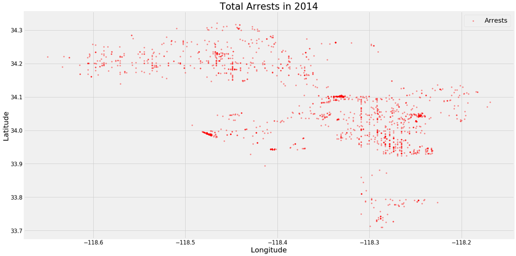

```python
# Total arrests in 2014
geo_plot_arrests(df_arrests_2014, 'Total Arrests in 2014')
```

```
Tally of Marijuana Related Arrests: 1535
```

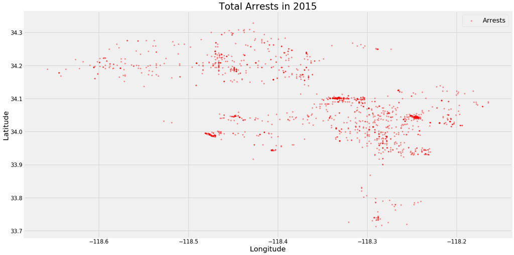

```python
# Total arrests in 2015
geo_plot_arrests(df_arrests_2015, 'Total Arrests in 2015')
```

```
Tally of Marijuana Related Arrests: 1386
```

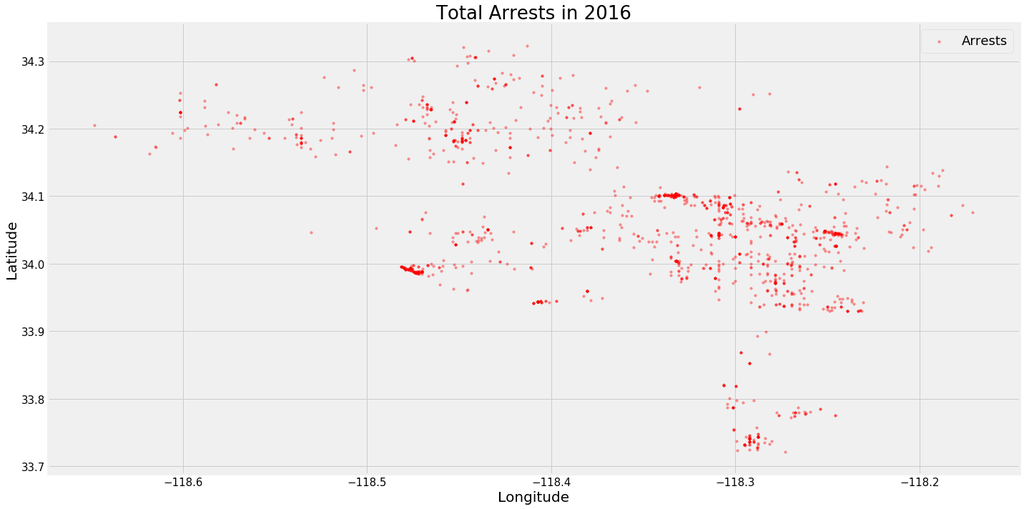

```python
# Total arrests in 2016
geo_plot_arrests(df_arrests_2016, 'Total Arrests in 2016')
```

```
Tally of Marijuana Related Arrests: 528
```

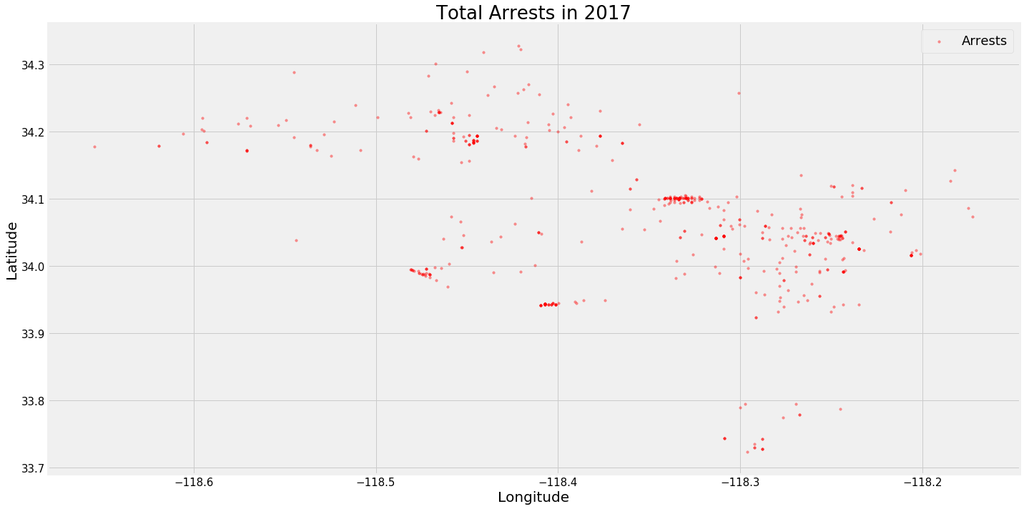

```python
# Total arrests in 2017
geo_plot_arrests(df_arrests_2017, 'Total Arrests in 2017')
```

```
Tally of Marijuana Related Arrests: 564
```

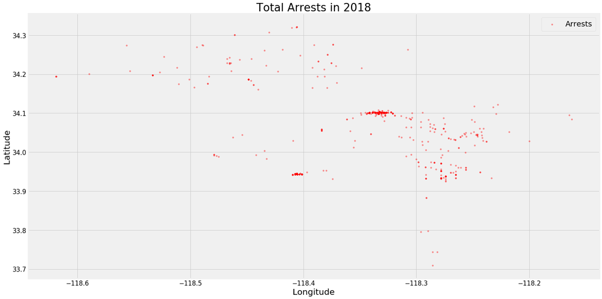

```python
# Total arrests in 2018
geo_plot_arrests(df_arrests_2018, 'Total Arrests in 2018')
```

```
Tally of Marijuana Related Arrests: 508
```

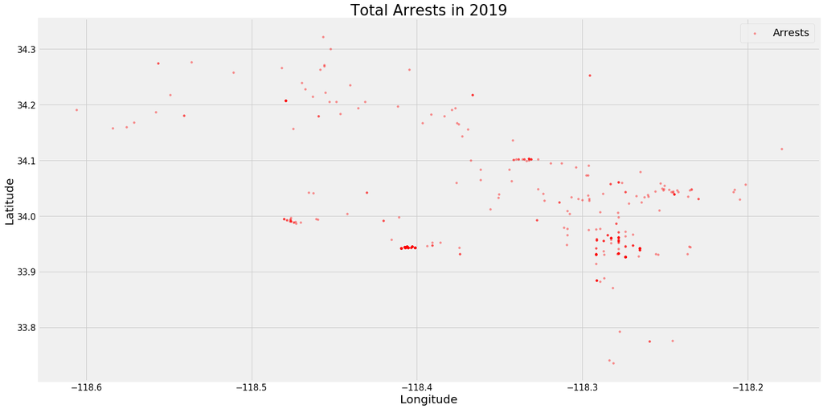

```python
# Total arrests in 2019
geo_plot_arrests(df_arrests_2019, 'Total Arrests in 2019')
```

The data and the plots show that there was a drop in arrests from 2014 to 2019, with a marked fall starting in 2017, the year the new marijuana laws came into force. Although correlation doesn't imply causation, this is nevertheless evidence that the law impacted marijuana arrests.

### Plot of Arrests x Dispensaries

```python
# Loading the dispensaries dataset
df_stores = pd.read_csv('files/df_stores.csv')
```

```python
df_stores.shape
```

```
(297, 10)
```

```python
df_stores.head()
```

|  | Unnamed: 0 | name | is_closed | url | rating | price | review_count | latitude | longitude | location |
| --- | --- | --- | --- | --- | --- | --- | --- | --- | --- | --- |
| 0 | 0 | California Caregivers Alliance | False | https://www.yelp.com/biz/california-caregivers... | 4.5 | NaN | 248 | 34.082350 | -118.272037 | (34.08235, -118.272037) |
| 1 | 1 | Herbarium | False | https://www.yelp.com/biz/herbarium-west-hollyw... | 4.5 | $$ | 230 | 34.088530 | -118.344600 | (34.08853, -118.3446) |
| 2 | 2 | MedMen Los Angeles - DTLA | False | https://www.yelp.com/biz/medmen-los-angeles-dt... | 4.0 | $$ | 303 | 34.044600 | -118.254440 | (34.0446, -118.25444) |
| 3 | 3 | Green Earth Collective | False | https://www.yelp.com/biz/green-earth-collectiv... | 4.5 | $$ | 183 | 34.122470 | -118.210670 | (34.12247, -118.21067) |
| 4 | 4 | HERB | False | https://www.yelp.com/biz/herb-los-angeles-3?ad... | 4.5 | $$ | 99 | 34.043499 | -118.250206 | (34.0434989929199, -118.250205993652) |

Closed dispensaries are not meaningful to the analysis and can skew results. Removing them:

```python
# Checking for closed stores
df_stores['is_closed'].value_counts()
```

```
False    296
True       1
Name: is_closed, dtype: int64
```

```python
# Checking the closed store's register
df_stores[df_stores['is_closed']]
```

|  | Unnamed: 0 | name | is_closed | url | rating | price | review_count | latitude | longitude | location |
| --- | --- | --- | --- | --- | --- | --- | --- | --- | --- | --- |
| 234 | 234 | CannaBuzz Store | True | https://www.yelp.com/biz/cannabuzz-store-los-a... | 1.0 | NaN | 1 | 34.04124 | -118.23775 | (34.04124, -118.23775) |

```python
# Removing the register
df_stores.drop(df_stores.index[234], inplace = True)
```

```python
# Checking for closed stores
df_stores['is_closed'].value_counts()
```

```
False    296
Name: is_closed, dtype: int64
```

For the rest of my analysis, only the name, latitude and longitude variables will be necessary. Dropping the other variables:

```python
# Filtering the dataframe
df_stores = df_stores[['name', 'latitude', 'longitude']]
```

```python
df_stores.head()
```

|  | name | latitude | longitude |
| --- | --- | --- | --- |
| 0 | California Caregivers Alliance | 34.082350 | -118.272037 |
| 1 | Herbarium | 34.088530 | -118.344600 |
| 2 | MedMen Los Angeles - DTLA | 34.044600 | -118.254440 |
| 3 | Green Earth Collective | 34.122470 | -118.210670 |
| 4 | HERB | 34.043499 | -118.250206 |

```python
# Statistical summary
df_stores.describe()
```

|  | latitude | longitude |
| --- | --- | --- |
| count | 296.000000 | 296.000000 |
| mean | 34.055510 | -118.313572 |
| std | 0.091237 | 0.134611 |
| min | 33.741532 | -118.624410 |
| 25% | 34.017272 | -118.383839 |
| 50% | 34.046515 | -118.323353 |
| 75% | 34.094220 | -118.250082 |
| max | 34.310078 | -117.455840 |

```python
# Saving the filtered dataframe
df_stores.to_csv('files/df_stores_02.csv', index = False)
```

```python
# Function to plot arrest location x store location
def geo_plot_02(dataframe_arrests, year):

    # Plot area
    fig, ax = plt.subplots(figsize = (25,15))

    # Scatterplot of Arrests
    plt.scatter(dataframe_arrests['longitude'], dataframe_arrests['latitude'], c = 'red', s = 12, label = 'Arrests')

    # Scatterplot of Dispensaries
    ax.scatter(df_stores['longitude'], df_stores['latitude'], c = 'b', s = 12, label = 'Dispensaries')

    # Labels and Legend
    plt.xlabel('Longitude', fontsize = 20)
    plt.ylabel('Latitude', fontsize = 20)
    plt.xticks(fontsize = 15)
    plt.yticks(fontsize = 15)
    plt.legend(fontsize = 18)
    plt.xlim(None, -118)
    plt.title(f'{year}: Arrests x Dispensaries', fontsize = 30)
    plt.tight_layout()
```

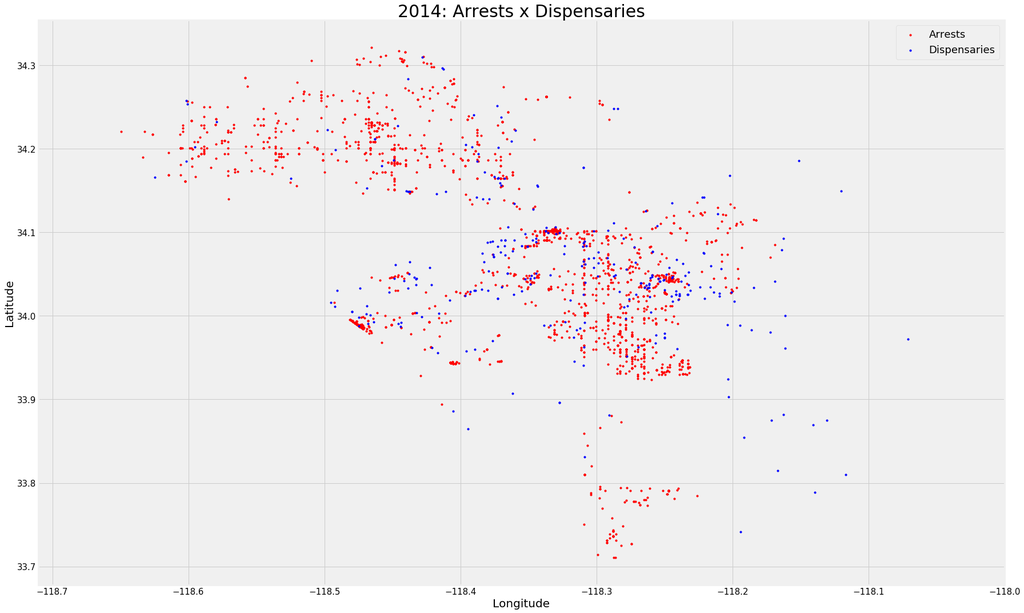

```python
geo_plot_02(df_arrests_2014, 2014)
```

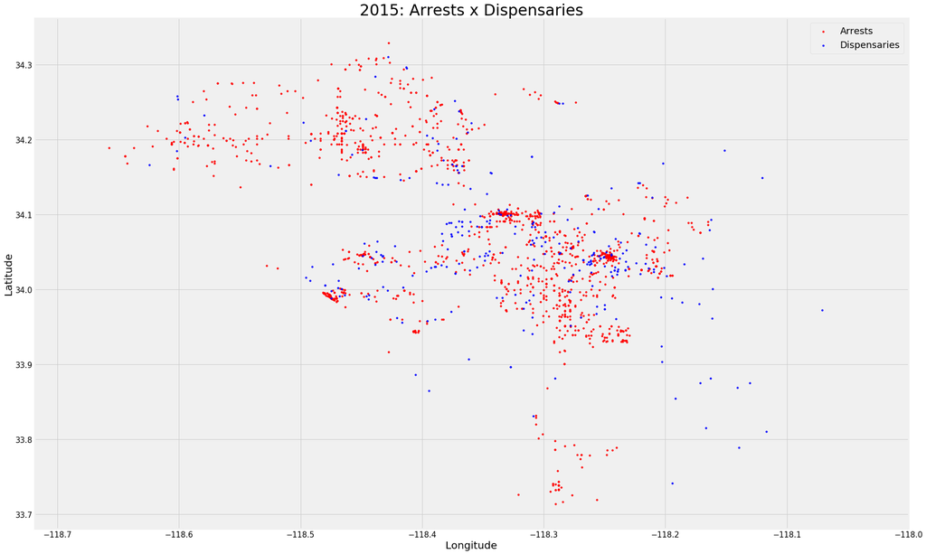

```python
geo_plot_02(df_arrests_2015, 2015)
```

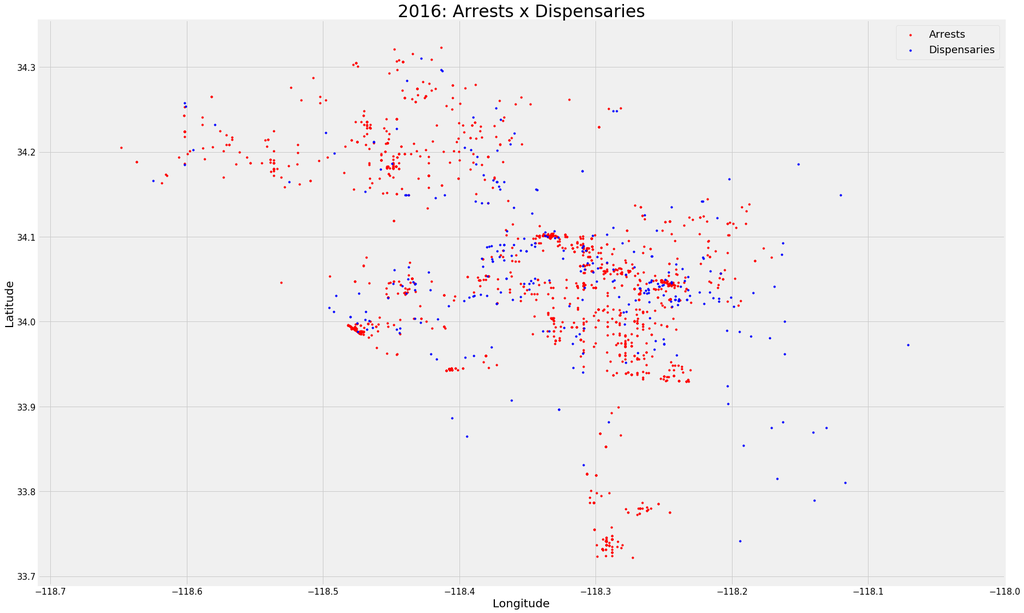

```python
geo_plot_02(df_arrests_2016, 2016)
```

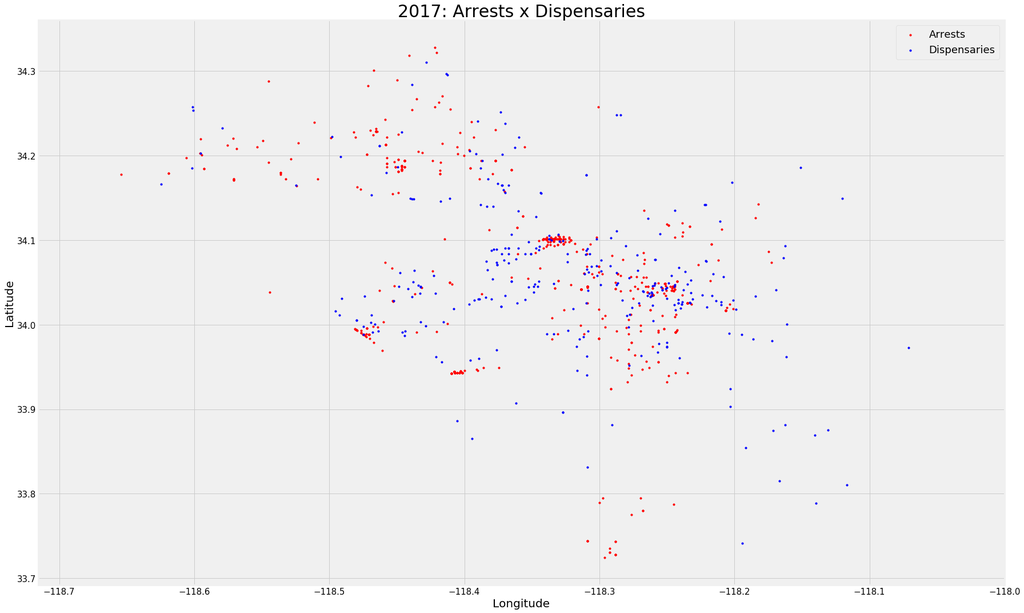

```python
geo_plot_02(df_arrests_2017, 2017)
```

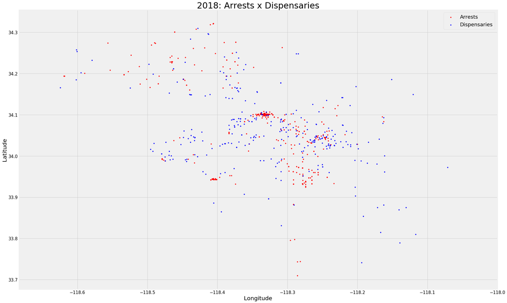

```python
geo_plot_02(df_arrests_2018, 2018)
```

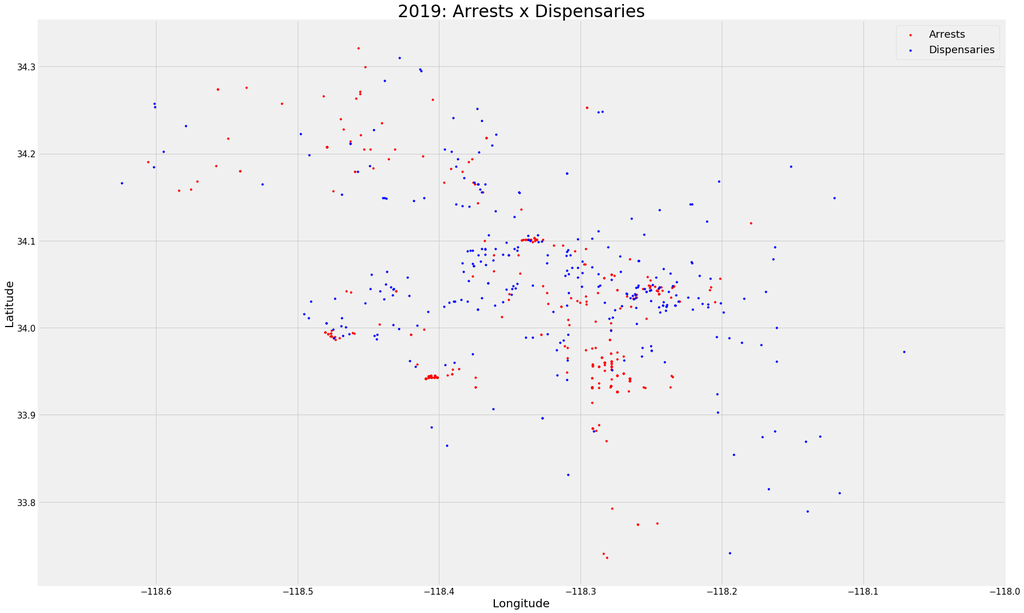

```python
geo_plot_02(df_arrests_2019, 2019)
```

### Plot of Arrests x Schools

```python
df_schools = pd.read_csv('files/df_schools.csv')
```

```python
df_schools.shape
```

```
(947, 7)
```

```python
df_schools.head()
```

|  | Unnamed: 0 | School | Zip Code | Grades | Local District | Board District | complete_address |
| --- | --- | --- | --- | --- | --- | --- | --- |
| 0 | 0 | Frank Del Olmo Elementary | 90004 | K- 5 | C | 2-Monica Garcia | 100 N New Hampshire Ave Los Angeles CA 90004 |
| 1 | 1 | 10th Street Elementary | 90015 | 1- 5 | C | 2-Monica Garcia | 1000 Grattan St Los Angeles CA 90015 |
| 2 | 2 | Elementary Community Day School | 91311 | K- 6 | XS | 3-Scott M Schmerelson | 10001 Jumilla Ave Chatsworth CA 91311 |
| 3 | 3 | Cesar E Chavez Learning Academy - Arts/Theatre... | 91340 | 9-12 | NE | 6-Kelly Gonez | 1001 Arroyo Ave San Fernando CA 91340 |
| 4 | 4 | San Pedro Senior High Gifted STEAM Magnet | 90731 | 9-12 | S | 7-Dr Richard A Vladovic | 1001 W 15th St San Pedro CA 90731 |

Geolocation data was not included in the school dataset, hence it will need to be obtained by other means. I'll use the school address paired with the google maps API to obtain the latitude and longitude of each school. Such data will also allow for the identification of duplicate entries (under different names) in the school list.

```python
!pip install -q googlemaps
```

```python
import googlemaps
```

```python
# API Key
gmaps_key = googlemaps.Client(key = '')
```

```python
# Lists to retrieve latitude and longitude
list_latitude = []
list_longitude = []
```

```python
# Loop through the school addresses list
# This may take a while
for address in df_schools['complete_address']:

    # Obtain the address' geocode
    g = gmaps_key.geocode(address)

    # Extract latitude and longitude
    try:
        lat = g[0]['geometry']['location']['lat']
        lng = g[0]['geometry']['location']['lng']
    # In case of error fill with NaN
    except:
        lat = np.NaN
        lng = np.NaN

    # Apprend latitude and longide to the lists
    list_latitude.append(lat)
    list_longitude.append(lng)
```

```python
# Adding the lists as columns on the schools dataframe
df_schools['latitude'] = list_latitude
df_schools['longitude'] = list_longitude
```

```python
# Checking for missing values
df_schools.isnull().sum()
```

```
Unnamed: 0          0
School              0
Zip Code            0
Grades              0
Local District      0
Board District      0
complete_address    0
latitude            8
longitude           8
dtype: int64
```

```python
# Using dropna() to avoid problems in case the API fails to fetch the geolocation of a school
df_schools = df_schools.dropna()
```

```python
df_schools.shape
```

[output not shown]

```python
# Creating a single column with all geolocation data
# This column can be used to filter duplicate entries
df_schools['coordinates'] = df_schools['latitude'].astype('str') + ', ' + df_schools['longitude'].astype(str)
```

```python
df_schools.head()
```

|  | Unnamed: 0 | School | Zip Code | Grades | Local District | Board District | complete_address | latitude | longitude | coordinates |
| --- | --- | --- | --- | --- | --- | --- | --- | --- | --- | --- |
| 0 | 0 | Frank Del Olmo Elementary | 90004 | K- 5 | C | 2-Monica Garcia | 100 N New Hampshire Ave Los Angeles CA 90004 | 34.072925 | -118.292591 | 34.072925, -118.292591 |
| 1 | 1 | 10th Street Elementary | 90015 | 1- 5 | C | 2-Monica Garcia | 1000 Grattan St Los Angeles CA 90015 | 34.048284 | -118.273264 | 34.0482844, -118.273264 |
| 2 | 2 | Elementary Community Day School | 91311 | K- 6 | XS | 3-Scott M Schmerelson | 10001 Jumilla Ave Chatsworth CA 91311 | 34.251825 | -118.563377 | 34.2518249, -118.5633769 |
| 3 | 3 | Cesar E Chavez Learning Academy - Arts/Theatre... | 91340 | 9-12 | NE | 6-Kelly Gonez | 1001 Arroyo Ave San Fernando CA 91340 | 34.288514 | -118.421011 | 34.2885136, -118.421011 |
| 4 | 4 | San Pedro Senior High Gifted STEAM Magnet | 90731 | 9-12 | S | 7-Dr Richard A Vladovic | 1001 W 15th St San Pedro CA 90731 | 33.730370 | -118.299342 | 33.73037, -118.2993419 |

```python
# Using the coordinates to remove duplicate entries
df_schools = df_schools[~df_schools.duplicated(subset = 'coordinates')]
```

```python
# Reseting index as rows were removed
df_schools.reset_index(drop = True, inplace = True)
```

```python
# Shape
df_schools.shape
```

```
(906, 9)
```

```python
# Statistical summary
df_schools.describe()
```

|  | Zip Code | latitude | longitude |
| --- | --- | --- | --- |
| count | 906.000000 | 906.000000 | 906.000000 |
| mean | 90475.435982 | 34.060198 | -118.334404 |
| std | 587.265043 | 0.128336 | 0.116058 |
| min | 90001.000000 | 33.711431 | -118.654393 |
| 25% | 90026.000000 | 33.981266 | -118.422510 |
| 50% | 90063.000000 | 34.044304 | -118.298979 |
| 75% | 91306.750000 | 34.168790 | -118.251660 |
| max | 91754.000000 | 34.319027 | -118.152239 |

```python
# The Unnamed: 0 column was the old index which became a column when the csv was imported
# It's not necessary. Removing it
df_schools.drop(labels = 'Unnamed: 0', axis = 1, inplace = True)
```

[output not shown]

```python
df_schools.head()
```

|  | School | Zip Code | Grades | Local District | Board District | complete_address | latitude | longitude | coordinates |
| --- | --- | --- | --- | --- | --- | --- | --- | --- | --- |
| 0 | Frank Del Olmo Elementary | 90004 | K- 5 | C | 2-Monica Garcia | 100 N New Hampshire Ave Los Angeles CA 90004 | 34.072925 | -118.292591 | 34.072925, -118.292591 |
| 1 | 10th Street Elementary | 90015 | 1- 5 | C | 2-Monica Garcia | 1000 Grattan St Los Angeles CA 90015 | 34.048284 | -118.273264 | 34.0482844, -118.273264 |
| 2 | Elementary Community Day School | 91311 | K- 6 | XS | 3-Scott M Schmerelson | 10001 Jumilla Ave Chatsworth CA 91311 | 34.251825 | -118.563377 | 34.2518249, -118.5633769 |
| 3 | Cesar E Chavez Learning Academy - Arts/Theatre... | 91340 | 9-12 | NE | 6-Kelly Gonez | 1001 Arroyo Ave San Fernando CA 91340 | 34.288514 | -118.421011 | 34.2885136, -118.421011 |
| 4 | San Pedro Senior High Gifted STEAM Magnet | 90731 | 9-12 | S | 7-Dr Richard A Vladovic | 1001 W 15th St San Pedro CA 90731 | 33.730370 | -118.299342 | 33.73037, -118.2993419 |

```python
# Saving the dataframe
df_schools.to_csv('files/df_schools_02.csv', index = False)
```

```python
# Function to plot arrest location x school location
def geo_plot_03(dataframe_arrests, year):

    # Plot area
    fig, ax = plt.subplots(figsize = (25,15))

    # Scatterplot of Arrests
    plt.scatter(dataframe_arrests['longitude'], dataframe_arrests['latitude'], c = 'red', s = 12, label = 'Arrests')

    # Scatterplot of Dispensaries
    ax.scatter(df_schools['longitude'], df_schools['latitude'], c = 'g', s = 12, label = 'Schools')

    # Labels and Legend
    plt.xlabel('Longitude', fontsize = 20)
    plt.ylabel('Latitude', fontsize = 20)
    plt.xticks(fontsize = 15)
    plt.yticks(fontsize = 15)
    plt.legend(fontsize = 18)
    plt.title(f'{year}: Arrests x Schools', fontsize = 30)
    plt.tight_layout()
```

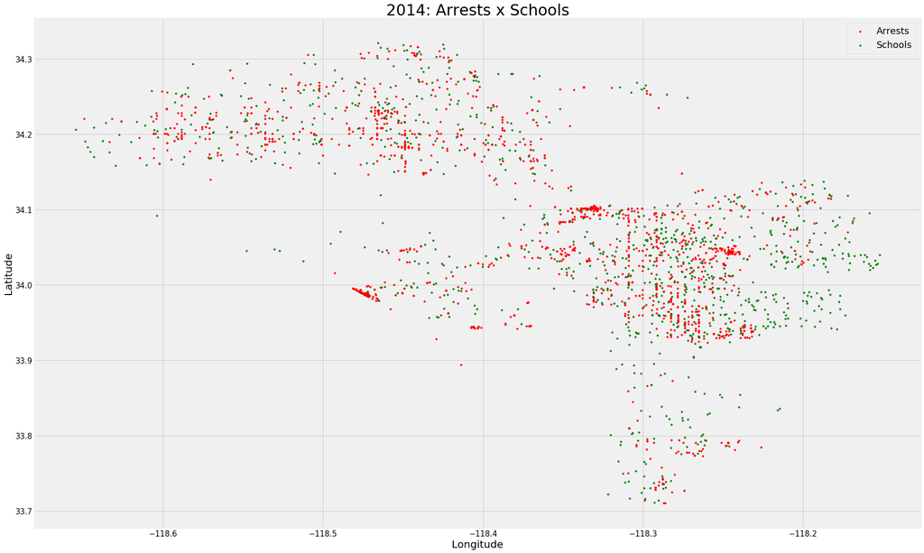

```python
geo_plot_03(df_arrests_2014, 2014)
```

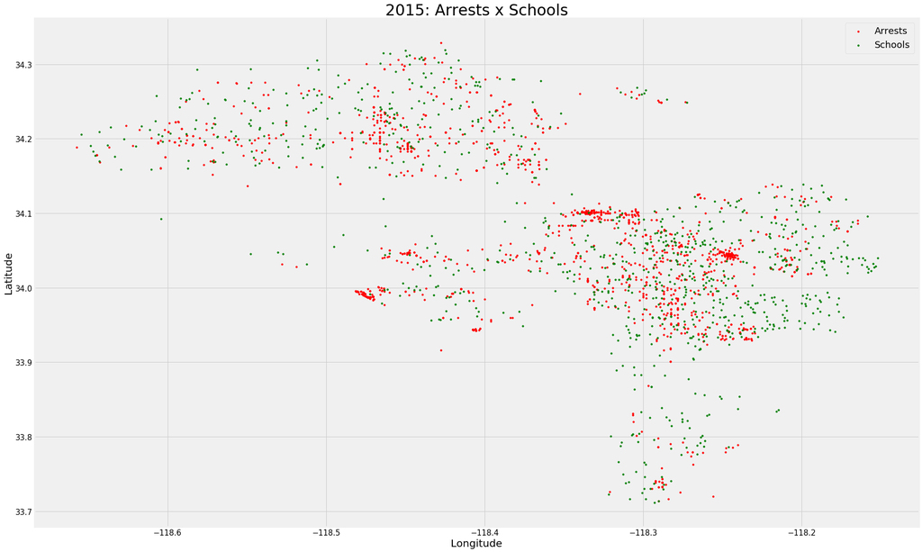

```python
geo_plot_03(df_arrests_2015, 2015)
```

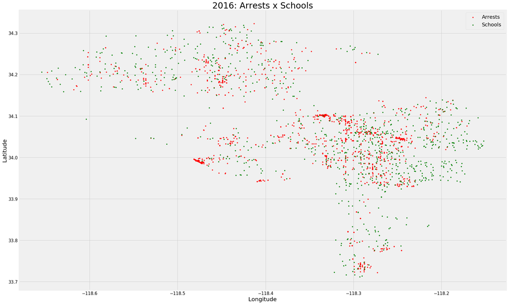

```python
geo_plot_03(df_arrests_2016, 2016)
```

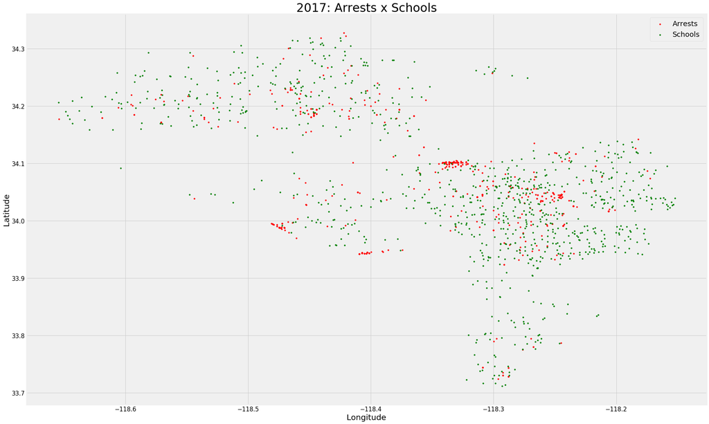

```python
geo_plot_03(df_arrests_2017, 2017)
```

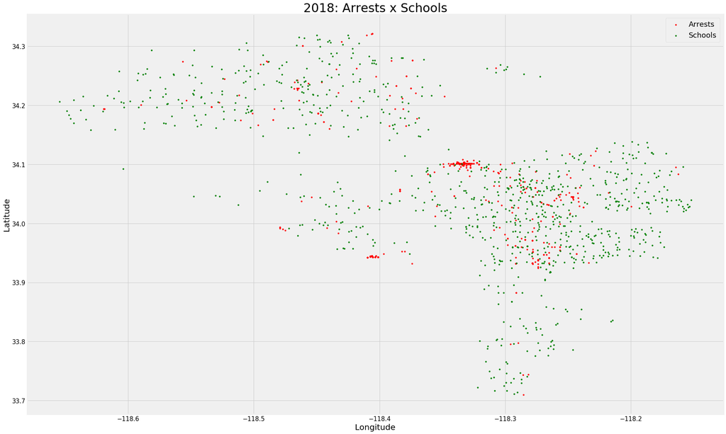

```python
geo_plot_03(df_arrests_2018, 2018)
```

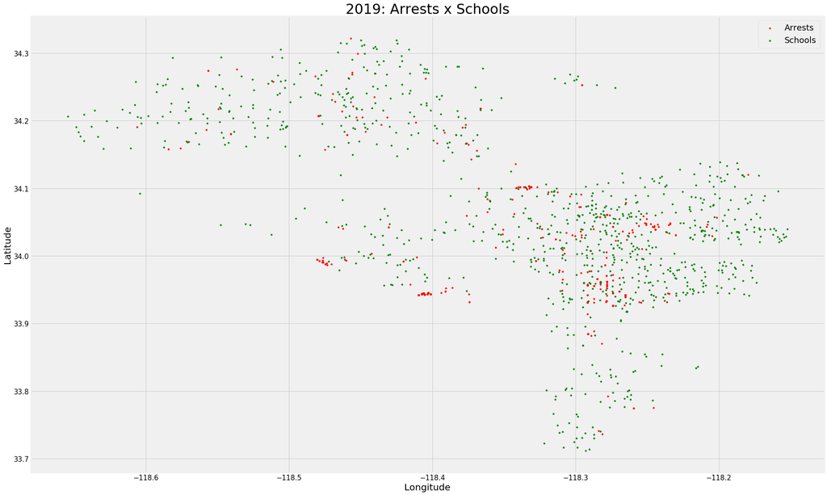

```python
geo_plot_03(df_arrests_2019, 2019)
```

There are schools everywhere, so it's hard to assess visually whether there is a higher incidence of marijuana arrests near schools.

As instructed, my next step will be using the geopy package to calculate the distance between schools and arrests.

## Distance from Arrests to Dispensaries and Schools

### Distance Between Arrest Locations and Dispensaries

Here I'm looking at how many stores where in the area around each arrest

```python
# Creating a dataframe to calculate distances - stores
df_stores_dist = df_stores[['name', 'latitude', 'longitude']]
```

```python
df_stores_dist.shape
```

```
(296, 3)
```

```python
df_stores_dist.head()
```

|  | name | latitude | longitude |
| --- | --- | --- | --- |
| 0 | California Caregivers Alliance | 34.082350 | -118.272037 |
| 1 | Herbarium | 34.088530 | -118.344600 |
| 2 | MedMen Los Angeles - DTLA | 34.044600 | -118.254440 |
| 3 | Green Earth Collective | 34.122470 | -118.210670 |
| 4 | HERB | 34.043499 | -118.250206 |

```python
# Creating a dataframe to calculate distances - arrests
df_arrests_dist = df_arrests[['Report ID', 'latitude', 'longitude']]
```

```python
# The index is skipping rows, reseting it
df_arrests_dist.reset_index(drop = True, inplace = True)
```

```python
df_arrests_dist.shape
```

```
(6226, 3)
```

```python
df_arrests_dist.head(3)
```

|  | Report ID | latitude | longitude |
| --- | --- | --- | --- |
| 0 | 5568617 | 34.1016 | -118.3350 |
| 1 | 5568629 | 34.1016 | -118.3350 |
| 2 | 5607178 | 34.0838 | -118.3614 |

```python
# Loading the geopy package which can be used to calculate distance between coordinates
# The function which does this is geodesic()
import geopy
from geopy.distance import geodesic
```

```python
%%time

# Loop through all stores and all arrests and calculate the distance
# This takes a while (more than 30 minutes)

for store in range(len(df_stores_dist)):

    # Get the data from that store
    store_name = df_stores_dist.iloc[store]['name']
    store_lat = df_stores_dist.iloc[store]['latitude']
    store_long = df_stores_dist.iloc[store]['longitude']

    # create new column on arrest_dist with store name
    df_arrests_dist[store_name] = np.NaN

    # Create an empty list to be filled with
    # The distance between arrest and that given store
    distance_list = []

    # Loop though all arrests
    for arrest in range(len(df_arrests_dist)):

        # Get the geolocation from arrest
        arrest_lat = df_arrests_dist.iloc[arrest]['latitude']
        arrest_long = df_arrests_dist.iloc[arrest]['longitude']

        # Calculate distance from arrest to store
        distance = geodesic((store_lat, store_long), (arrest_lat, arrest_long)).miles

        # Add to the list containing all distances from a given store
        distance_list.append(distance)

    # Fill the store name column with the distances list
    df_arrests_dist[store_name] = distance_list
```

```
Wall time: 43min 5s
```

```python
df_arrests_dist.to_csv('files/distances_dispensaries.csv')
```

```python
df_arrests_dist
```

|  | Report ID | latitude | longitude | California Caregivers Alliance | Herbarium | MedMen Los Angeles - DTLA | Green Earth Collective | HERB | Kushfly | The Higher Path | ... | Spectwonders | Khonsu's Collective | Cannacureshop | Stiiizy Weed Delivery | Trilogy Wellness | The Blue Diamond Center | Reefer Madness Clone Company | Rolling Up Delivery Services | OVO FINEST | McLeonel dispensary |
| --- | --- | --- | --- | --- | --- | --- | --- | --- | --- | --- | --- | --- | --- | --- | --- | --- | --- | --- | --- | --- | --- |
| 0 | 5568617 | 34.1016 | -118.3350 | 3.846579 | 1.055725 | 6.065042 | 7.271511 | 6.300019 | 1.914766 | 6.853097 | ... | 15.634180 | 0.119404 | 1.549481 | 5.416763 | 43.626572 | 3.720157 | 33.563909 | 37.581619 | 39.645966 | 52.333731 |
| 1 | 5568629 | 34.1016 | -118.3350 | 3.846579 | 1.055725 | 6.065042 | 7.271511 | 6.300019 | 1.914766 | 6.853097 | ... | 15.634180 | 0.119404 | 1.549481 | 5.416763 | 43.626572 | 3.720157 | 33.563909 | 37.581619 | 39.645966 | 52.333731 |
| 2 | 5607178 | 34.0838 | -118.3614 | 5.125880 | 1.017099 | 6.704001 | 9.043892 | 6.956954 | 3.135336 | 6.375281 | ... | 15.416857 | 1.855468 | 0.600893 | 7.095336 | 45.160692 | 5.030097 | 34.207656 | 38.891827 | 41.101419 | 53.499184 |
| 3 | 5616516 | 33.9428 | -118.4054 | 12.292510 | 10.633230 | 11.150758 | 16.679867 | 11.293960 | 13.176048 | 14.372352 | ... | 11.949733 | 11.623553 | 10.185298 | 17.071368 | 48.939045 | 15.068000 | 32.966616 | 41.323891 | 44.425795 | 54.636803 |
| 4 | 5616188 | 34.1667 | -118.3965 | 9.203280 | 6.154616 | 11.711705 | 11.077266 | 11.935715 | 3.924004 | 2.758385 | ... | 21.287644 | 5.635323 | 6.305098 | 5.031280 | 47.351137 | 3.165782 | 39.014091 | 41.993391 | 43.651658 | 57.007198 |
| ... | ... | ... | ... | ... | ... | ... | ... | ... | ... | ... | ... | ... | ... | ... | ... | ... | ... | ... | ... | ... | ... |
| 6221 | 5608841 | 33.9922 | -118.3276 | 6.983746 | 6.710759 | 5.538437 | 11.207795 | 5.677312 | 9.397726 | 12.600659 | ... | 9.428619 | 7.557099 | 6.429712 | 12.799623 | 43.876664 | 11.266752 | 29.700995 | 36.623164 | 39.469040 | 50.470909 |
| 6222 | 5608817 | 33.9922 | -118.3276 | 6.983746 | 6.710759 | 5.538437 | 11.207795 | 5.677312 | 9.397726 | 12.600659 | ... | 9.428619 | 7.557099 | 6.429712 | 12.799623 | 43.876664 | 11.266752 | 29.700995 | 36.623164 | 39.469040 | 50.470909 |
| 6223 | 5607957 | 33.9432 | -118.4013 | 12.125538 | 10.532117 | 10.951188 | 16.502507 | 11.091994 | 13.091117 | 14.379368 | ... | 11.726920 | 11.520181 | 10.089127 | 16.970902 | 48.703420 | 14.986992 | 32.743496 | 41.086769 | 44.189353 | 54.402916 |
| 6224 | 5611605 | 33.9420 | -118.4095 | 12.483114 | 10.764484 | 11.368913 | 16.879015 | 11.514012 | 13.291205 | 14.396604 | ... | 12.167033 | 11.756588 | 10.312090 | 17.200508 | 49.180934 | 15.178964 | 33.183789 | 41.564068 | 44.667513 | 54.869409 |
| 6225 | 5607182 | 34.0382 | -118.2603 | 3.116618 | 5.951259 | 0.554649 | 6.468228 | 0.684713 | 7.908279 | 12.833999 | ... | 9.869101 | 6.202127 | 6.062438 | 9.995559 | 39.596138 | 9.353346 | 27.614863 | 32.808075 | 35.332462 | 47.159513 |

6226 rows × 294 columns

```python
# Creating a new dataframe with only distance data
df_dist_arrest_store = df_arrests_dist.drop(['Report ID', 'latitude', 'longitude'], axis = 1)
```

```python
df_dist_arrest_store.head(3)
```

|  | California Caregivers Alliance | Herbarium | MedMen Los Angeles - DTLA | Green Earth Collective | HERB | Kushfly | The Higher Path | Cannabis Cafe | MedMen Venice Beach - Abbot Kinney | Exhale Med Center | ... | Spectwonders | Khonsu's Collective | Cannacureshop | Stiiizy Weed Delivery | Trilogy Wellness | The Blue Diamond Center | Reefer Madness Clone Company | Rolling Up Delivery Services | OVO FINEST | McLeonel dispensary |
| --- | --- | --- | --- | --- | --- | --- | --- | --- | --- | --- | --- | --- | --- | --- | --- | --- | --- | --- | --- | --- | --- |
| 0 | 3.846579 | 1.055725 | 6.065042 | 7.271511 | 6.300019 | 1.914766 | 6.853097 | 0.818004 | 10.785022 | 2.518391 | ... | 15.634180 | 0.119404 | 1.549481 | 5.416763 | 43.626572 | 3.720157 | 33.563909 | 37.581619 | 39.645966 | 52.333731 |
| 1 | 3.846579 | 1.055725 | 6.065042 | 7.271511 | 6.300019 | 1.914766 | 6.853097 | 0.818004 | 10.785022 | 2.518391 | ... | 15.634180 | 0.119404 | 1.549481 | 5.416763 | 43.626572 | 3.720157 | 33.563909 | 37.581619 | 39.645966 | 52.333731 |
| 2 | 5.125880 | 1.017099 | 6.704001 | 9.043892 | 6.956954 | 3.135336 | 6.375281 | 1.150360 | 8.849409 | 0.923056 | ... | 15.416857 | 1.855468 | 0.600893 | 7.095336 | 45.160692 | 5.030097 | 34.207656 | 38.891827 | 41.101419 | 53.499184 |

3 rows × 291 columns

```python
# For each arrest count how many stores were in a 0.5 mile range
df_arrests_dist['store_0.5_mile'] = (df_dist_arrest_store < 0.5).sum(axis = 1)
```

```python
# For each arrest count how many stores were in a 1 mile range
df_arrests_dist['store_1_mile'] = (df_dist_arrest_store < 1).sum(axis = 1)
```

```python
# Problem prevention: Checking df_arrests and df_arrests_dist
# To see if the 'Report ID' columns still match
len(df_arrests['Report ID'].unique()) == len(df_arrests_dist['Report ID'].unique())
```

```
True
```

```python
# Adding the columns with the calculated distances back to df_arrests
df_arrests = df_arrests.merge(df_arrests_dist[['Report ID', 'store_0.5_mile', 'store_1_mile']],
                            left_on = 'Report ID',
                            right_on = 'Report ID')
```

```python
df_arrests.head(2)
```

[output not shown]

```python
# Dropping the 'Unnamed: 0' column
df_arrests = df_arrests.drop('Unnamed: 0', 1)
```

[output not shown]

```python
# Saving df_arrests to disk
df_arrests.to_csv('files/df_arrests_03.csv', index = False)
```

### Distance Between Arrests and Schools

Here I'm looking at how many arrests happened near each school

AND at how many schools were near each arrest

```python
# Creating a dataframe to calculate distances - stores
df_schools_dist = df_schools[['School', 'latitude', 'longitude']].dropna()
```

```python
df_schools_dist.shape
```

```
(906, 3)
```

```python
df_schools.isnull().sum()
```

```
School              0
Zip Code            0
Grades              0
Local District      0
Board District      0
complete_address    0
latitude            0
longitude           0
coordinates         0
dtype: int64
```

```python
df_schools_dist
```

|  | School | latitude | longitude |
| --- | --- | --- | --- |
| 0 | Frank Del Olmo Elementary | 34.072925 | -118.292591 |
| 1 | 10th Street Elementary | 34.048284 | -118.273264 |
| 2 | Elementary Community Day School | 34.251825 | -118.563377 |
| 3 | Cesar E Chavez Learning Academy - Arts/Theatre... | 34.288514 | -118.421011 |
| 4 | San Pedro Senior High Gifted STEAM Magnet | 33.730370 | -118.299342 |
| ... | ... | ... | ... |
| 901 | Madison Elementary | 33.945729 | -118.214513 |
| 902 | Stonehurst Avenue Elementary STEAM Magnet | 34.249666 | -118.369889 |
| 903 | Mariposa-Nabi Primary Center | 34.053092 | -118.299215 |
| 904 | 99th Street Elementary | 33.946302 | -118.258281 |
| 905 | Alfred B Nobel Charter Middle School | 34.251085 | -118.551358 |

906 rows × 3 columns

```python
# Dataframe for distance between arrests and schools
df_dist_arrest_school = df_arrests[['Report ID', 'latitude', 'longitude']]
```

```python
# The index is skipping rows, reseting it
df_dist_arrest_school.reset_index(drop = True, inplace = True)
```

```python
df_dist_arrest_school
```

[output not shown]

```python
%%time

# Loop through all stores and all arrests and calculate the distance
# This takes a long time! (2 hours or so)

for store in range(len(df_schools_dist)):

    # Get the data from that store
    store_name = df_schools_dist.iloc[store]['School']
    store_lat = df_schools_dist.iloc[store]['latitude']
    store_long = df_schools_dist.iloc[store]['longitude']

    # create new column on arrest_dist with store name
    df_dist_arrest_school[store_name] = np.NaN

    # Create an empty list to be filled with
    # The distance between arrest and that given store
    distance_list = []

    # Loop though all arrests
    for arrest in range(len(df_arrests_dist)):

        # Get the geolocation from arrest
        arrest_lat = df_arrests_dist.iloc[arrest]['latitude']
        arrest_long = df_arrests_dist.iloc[arrest]['longitude']

        # Calculate distance from arrest to store
        distance = geodesic((store_lat, store_long), (arrest_lat, arrest_long)).miles

        # Add to the list containing all distances from a given store
        distance_list.append(distance)

    # Fill the store name column with the distances list
    df_dist_arrest_school[store_name] = distance_list
```

```
Wall time: 1h 44min 27s
```

```python
df_dist_arrest_school.to_csv('files/distances_schools.csv')
```

```python
df_dist_arrest_school.shape
```

```
(6226, 909)
```

```python
df_dist_arrest_school.head(2)
```

[output not shown]

```python
df_dist_arrest_school_2 = df_dist_arrest_school.drop(['Report ID', 'latitude', 'longitude'], axis = 1)
```

```python
df_dist_arrest_school_2.head(2)
```

|  | Frank Del Olmo Elementary | 10th Street Elementary | Elementary Community Day School | Cesar E Chavez Learning Academy - Arts/Theatre/Entertain Mag | San Pedro Senior High Gifted STEAM Magnet | Normont Elementary | Stoney Point Continuation High | Montara Avenue Elementary | Chatsworth Charter High School | Our Community Charter School | ... | Beachy Avenue Elementary | Hobart Boulevard Elementary DL Two-Way Im Spanish | San Miguel Elementary DL World Lang Im Mandarin | Wadsworth Avenue Elementary | Topeka Drive Charter for Advanced Studies | Madison Elementary | Stonehurst Avenue Elementary STEAM Magnet | Mariposa-Nabi Primary Center | 99th Street Elementary | Alfred B Nobel Charter Middle School |
| --- | --- | --- | --- | --- | --- | --- | --- | --- | --- | --- | --- | --- | --- | --- | --- | --- | --- | --- | --- | --- | --- |
| 0 | 3.133832 | 5.103094 | 16.684527 | 13.792930 | 25.668208 | 21.199880 | 17.826477 | 12.742390 | 17.786585 | 16.745153 | ... | 11.675055 | 3.729257 | 13.236804 | 7.709947 | 15.750312 | 12.776177 | 10.399451 | 3.923088 | 11.573941 | 16.117688 |
| 1 | 3.133832 | 5.103094 | 16.684527 | 13.792930 | 25.668208 | 21.199880 | 17.826477 | 12.742390 | 17.786585 | 16.745153 | ... | 11.675055 | 3.729257 | 13.236804 | 7.709947 | 15.750312 | 12.776177 | 10.399451 | 3.923088 | 11.573941 | 16.117688 |
| 2 | 4.016920 | 5.617011 | 16.371597 | 14.517362 | 24.619110 | 20.219608 | 17.412544 | 12.643768 | 17.388639 | 16.434939 | ... | 12.121288 | 3.815014 | 13.263019 | 7.807277 | 15.490766 | 12.713676 | 11.442783 | 4.147576 | 11.173228 | 15.855267 |

3 rows × 906 columns

```python
# For each ARREST count how many SCHOOLS were in a 0.5 mile range
df_dist_arrest_school['school_0.5_mile'] = (df_dist_arrest_school_2 < 0.5).sum(axis = 1)
```

```python
# For each ARREST count how many SCHOOLS were in a 1 mile range
df_dist_arrest_school['school_1_mile'] = (df_dist_arrest_school_2 < 1).sum(axis = 1)
```

```python
df_dist_arrest_school.head(2)
```

|  | Report ID | latitude | longitude | Frank Del Olmo Elementary | 10th Street Elementary | Elementary Community Day School | Cesar E Chavez Learning Academy - Arts/Theatre/Entertain Mag | San Pedro Senior High Gifted STEAM Magnet | Normont Elementary | Stoney Point Continuation High | ... | San Miguel Elementary DL World Lang Im Mandarin | Wadsworth Avenue Elementary | Topeka Drive Charter for Advanced Studies | Madison Elementary | Stonehurst Avenue Elementary STEAM Magnet | Mariposa-Nabi Primary Center | 99th Street Elementary | Alfred B Nobel Charter Middle School | arrest_0.5_mile | arrest_1_mile |
| --- | --- | --- | --- | --- | --- | --- | --- | --- | --- | --- | --- | --- | --- | --- | --- | --- | --- | --- | --- | --- | --- |
| 0 | 5568617 | 34.1016 | -118.3350 | 3.133832 | 5.103094 | 16.684527 | 13.792930 | 25.668208 | 21.199880 | 17.826477 | ... | 13.236804 | 7.709947 | 15.750312 | 12.776177 | 10.399451 | 3.923088 | 11.573941 | 16.117688 | 2 | 5 |
| 1 | 5568629 | 34.1016 | -118.3350 | 3.133832 | 5.103094 | 16.684527 | 13.792930 | 25.668208 | 21.199880 | 17.826477 | ... | 13.236804 | 7.709947 | 15.750312 | 12.776177 | 10.399451 | 3.923088 | 11.573941 | 16.117688 | 2 | 5 |
| 2 | 5607178 | 34.0838 | -118.3614 | 4.016920 | 5.617011 | 16.371597 | 14.517362 | 24.619110 | 20.219608 | 17.412544 | ... | 13.263019 | 7.807277 | 15.490766 | 12.713676 | 11.442783 | 4.147576 | 11.173228 | 15.855267 | 4 | 8 |

3 rows × 911 columns

```python
# Now transposing the original distances dataframe in order to count the number of arrests near each school
df_dist_school_arrest = df_dist_arrest_school_2.T
```

```python
# For each SCHOOL count how many ARREST happened in a 0.5 mile range
df_dist_school_arrest['arrest_0.5_mile'] = (df_dist_school_arrest < 0.5).sum(axis = 1)
```

```python
# For each SCHOOL count how many ARREST happened in a 1 mile range
df_dist_school_arrest['arrest_1_mile'] = (df_dist_school_arrest < 1).sum(axis = 1)
```

```python
df_dist_school_arrest.head(2)
```

[output not shown]

3 rows × 6229 columns

```python
df_dist_school_arrest.reset_index(inplace = True)
```

```python
df_dist_school_arrest.rename(columns = {'index': 'School'}, inplace = True)
```

```python
# Problem prevention: Checking df_arrests and df_arrests_dist
# To see if the 'Report ID' columns still match
len(df_schools['School'].unique()) == len(df_dist_school_arrest['School'].unique())
```

```
True
```

```python
# Adding two columns to the schools dataframe
# With the tally of how many arrests happened nearby
df_schools = df_schools.merge(df_dist_school_arrest[['School', 'arrest_0.5_mile', 'arrest_1_mile']],
                            left_on = 'School',
                            right_on = 'School')
```

```python
df_schools.head(2)
```

|  | School | Zip Code | Grades | Local District | Board District | complete_address | latitude | longitude | coordinates | arrest_0.5_mile | arrest_1_mile |
| --- | --- | --- | --- | --- | --- | --- | --- | --- | --- | --- | --- |
| 0 | Frank Del Olmo Elementary | 90004 | K- 5 | C | 2-Monica Garcia | 100 N New Hampshire Ave Los Angeles CA 90004 | 34.072925 | -118.292591 | 34.072925, -118.292591 | 28 | 95 |
| 1 | 10th Street Elementary | 90015 | 1- 5 | C | 2-Monica Garcia | 1000 Grattan St Los Angeles CA 90015 | 34.048284 | -118.273264 | 34.0482844, -118.273264 | 26 | 141 |
| 2 | Elementary Community Day School | 91311 | K- 6 | XS | 3-Scott M Schmerelson | 10001 Jumilla Ave Chatsworth CA 91311 | 34.251825 | -118.563377 | 34.2518249, -118.5633769 | 1 | 3 |

```python
df_arrests.head(2)
```

|  | Report ID | Arrest Date | Time | Area ID | Area Name | Reporting District | Age | Sex Code | Descent Code | Charge Group Code | ... | Address | Cross Street | Location | latitude | longitude | marijuana_related | store_0.5_mile_x | store_1_mile_x | store_0.5_mile_y | store_1_mile_y |
| --- | --- | --- | --- | --- | --- | --- | --- | --- | --- | --- | --- | --- | --- | --- | --- | --- | --- | --- | --- | --- | --- |
| 0 | 5568617 | 2019-03-09 | 2015.0 | 6 | Hollywood | 646 | 29 | M | O | 16.0 | ... | CHEROKEE | HOLLYWOOD | ['34.1016', '-118.335'] | 34.1016 | -118.3350 | possession marijuana for sale | 7 | 8 | 7 | 8 |
| 1 | 5568629 | 2019-03-09 | 2015.0 | 6 | Hollywood | 646 | 25 | M | B | 16.0 | ... | CHEROKEE | HOLLYWOOD | ['34.1016', '-118.335'] | 34.1016 | -118.3350 | possession marijuana for sale | 7 | 8 | 7 | 8 |
| 2 | 5607178 | 2019-04-21 | 2115.0 | 7 | Wilshire | 702 | 42 | M | B | 16.0 | ... | MELROSE AV | FAIRFAX AV | ['34.0838', '-118.3614'] | 34.0838 | -118.3614 | poss/sale marij ovr 21 employ per 20/belw | 4 | 13 | 4 | 13 |

3 rows × 24 columns

```python
# Adding two columns to the arrests dataframe
# With the tally of how many schools were nearby
df_arrests['school_0.5_mile'] = (df_dist_arrest_school_2 < 0.5).sum(axis =1)
df_arrests['school_1_mile'] = (df_dist_arrest_school_2 < 1).sum(axis =1)
```

```python
df_arrests.head(2)
```

|  | Report ID | Arrest Date | Time | Area ID | Area Name | Reporting District | Age | Sex Code | Descent Code | Charge Group Code | ... | Location | latitude | longitude | marijuana_related | store_0.5_mile_x | store_1_mile_x | store_0.5_mile_y | store_1_mile_y | school_0.5_mile | school_1_mile |
| --- | --- | --- | --- | --- | --- | --- | --- | --- | --- | --- | --- | --- | --- | --- | --- | --- | --- | --- | --- | --- | --- |
| 0 | 5568617 | 2019-03-09 | 2015.0 | 6 | Hollywood | 646 | 29 | M | O | 16.0 | ... | ['34.1016', '-118.335'] | 34.1016 | -118.335 | possession marijuana for sale | 7 | 8 | 7 | 8 | 2 | 5 |
| 1 | 5568629 | 2019-03-09 | 2015.0 | 6 | Hollywood | 646 | 25 | M | B | 16.0 | ... | ['34.1016', '-118.335'] | 34.1016 | -118.335 | possession marijuana for sale | 7 | 8 | 7 | 8 | 2 | 5 |

2 rows × 26 columns

```python
df_arrests.columns
```

```
Index(['Report ID', 'Arrest Date', 'Time', 'Area ID', 'Area Name',
       'Reporting District', 'Age', 'Sex Code', 'Descent Code',
       'Charge Group Code', 'Charge Group Description', 'Arrest Type Code',
       'Charge', 'Charge Description', 'Address', 'Cross Street', 'Location',
       'latitude', 'longitude', 'marijuana_related', 'store_0.5_mile_x',
       'store_1_mile_x', 'store_0.5_mile_y', 'store_1_mile_y',
       'school_0.5_mile', 'school_1_mile'],
      dtype='object')
```

```python
# Saving to disk all dataframes
df_arrests.to_csv('files/df_arrests_04.csv', index = False)
df_schools.to_csv('files/df_schools_03.csv' ,index = False)
```

## Arrest Time Series

```python
# Range of dates for indexing
index_dates = pd.date_range('2014-01-01', '2019-12-31')
```

```python
df_arrests
```

|  | Report ID | Arrest Date | Time | Area ID | Area Name | Reporting District | Age | Sex Code | Descent Code | Charge Group Code | ... | Location | latitude | longitude | marijuana_related | store_0.5_mile_x | store_1_mile_x | store_0.5_mile_y | store_1_mile_y | school_0.5_mile | school_1_mile |
| --- | --- | --- | --- | --- | --- | --- | --- | --- | --- | --- | --- | --- | --- | --- | --- | --- | --- | --- | --- | --- | --- |
| 0 | 5568617 | 2019-03-09 | 2015.0 | 6 | Hollywood | 646 | 29 | M | O | 16.0 | ... | ['34.1016', '-118.335'] | 34.1016 | -118.3350 | possession marijuana for sale | 7 | 8 | 7 | 8 | 2 | 5 |
| 1 | 5568629 | 2019-03-09 | 2015.0 | 6 | Hollywood | 646 | 25 | M | B | 16.0 | ... | ['34.1016', '-118.335'] | 34.1016 | -118.3350 | possession marijuana for sale | 7 | 8 | 7 | 8 | 2 | 5 |
| 2 | 5607178 | 2019-04-21 | 2115.0 | 7 | Wilshire | 702 | 42 | M | B | 16.0 | ... | ['34.0838', '-118.3614'] | 34.0838 | -118.3614 | poss/sale marij ovr 21 employ per 20/belw | 4 | 13 | 4 | 13 | 4 | 8 |
| 3 | 5616516 | 2019-05-01 | 1045.0 | 14 | Pacific | 1494 | 26 | M | B | 16.0 | ... | ['33.9428', '-118.4054'] | 33.9428 | -118.4054 | sale/trans >28.5g marijuana or >4g | 0 | 0 | 0 | 0 | 0 | 0 |
| 4 | 5616188 | 2019-05-01 | 5.0 | 15 | N Hollywood | 1543 | 27 | M | B | 16.0 | ... | ['34.1667', '-118.3965'] | 34.1667 | -118.3965 | sale/trans >28.5g marijuana or >4g | 0 | 1 | 0 | 1 | 3 | 4 |
| ... | ... | ... | ... | ... | ... | ... | ... | ... | ... | ... | ... | ... | ... | ... | ... | ... | ... | ... | ... | ... | ... |
| 6221 | 5608841 | 2019-04-23 | 1020.0 | 12 | 77th Street | 1211 | 57 | M | B | 16.0 | ... | ['33.9922', '-118.3276'] | 33.9922 | -118.3276 | cultivating <6 marijuana plants | 2 | 4 | 2 | 4 | 7 | 11 |
| 6222 | 5608817 | 2019-04-23 | 1020.0 | 12 | 77th Street | 1211 | 57 | M | B | 16.0 | ... | ['33.9922', '-118.3276'] | 33.9922 | -118.3276 | cultivating <6 marijuana plants | 2 | 4 | 2 | 4 | 7 | 11 |
| 6223 | 5607957 | 2019-04-22 | 1531.0 | 14 | Pacific | 1494 | 36 | M | O | 16.0 | ... | ['33.9432', '-118.4013'] | 33.9432 | -118.4013 | transport/sell/furnish/etc marijuana | 0 | 0 | 0 | 0 | 0 | 0 |
| 6224 | 5611605 | 2019-04-26 | 1130.0 | 14 | Pacific | 1494 | 22 | M | B | 16.0 | ... | ['33.942', '-118.4095'] | 33.9420 | -118.4095 | transport/sell/furnish/etc marijuana | 0 | 0 | 0 | 0 | 0 | 0 |
| 6225 | 5607182 | 2019-04-21 | 2140.0 | 1 | Central | 185 | 19 | M | H | 16.0 | ... | ['34.0382', '-118.2603'] | 34.0382 | -118.2603 | possess marijuana for sale | 10 | 17 | 10 | 17 | 0 | 10 |

6226 rows × 26 columns

```python
# Dataframe with arrests grouped per day (categorial variables will disappear)
df_arrests_g = df_arrests.groupby('Arrest Date').sum()
```

```python
# Tally of arrest near schools per day
df_arrests_g['school_0.5_mile'].head()
```

```
Arrest Date
2014-01-01    14
2014-01-02    15
2014-01-03     1
2014-01-04     8
2014-01-05     5
Name: school_0.5_mile, dtype: int64
```

```python
# Tally of arrest near schools per day
df_arrests_g['school_1_mile'].head()
```

```
Arrest Date
2014-01-01    39
2014-01-02    48
2014-01-03    10
2014-01-04    32
2014-01-05    19
Name: school_1_mile, dtype: int64
```

```python
# Making dataframes
df_arrests_half_mile_schools = pd.DataFrame(df_arrests_g['school_0.5_mile'])
df_arrests_one_mile_schools = pd.DataFrame(df_arrests_g['school_1_mile'])
```

```python
df_arrests_half_mile_schools.head()
```

| Arrest Date | school_0.5_mile |
| --- | --- |
| 2014-01-01 | 14 |
| 2014-01-02 | 15 |
| 2014-01-03 | 1 |
| 2014-01-04 | 8 |
| 2014-01-05 | 5 |

```python
df_arrests_one_mile_schools.head()
```

| Arrest Date | school_1_mile |
| --- | --- |
| 2014-01-01 | 39 |
| 2014-01-02 | 48 |
| 2014-01-03 | 10 |
| 2014-01-04 | 32 |
| 2014-01-05 | 19 |

The dataframe index is of type: Index

To be able to tally the monthly totals, it must be of type: DateTimeIndex

```python
# Checking index type
df_arrests_half_mile_schools.index
```

```
Index(['2014-01-01', '2014-01-02', '2014-01-03', '2014-01-04', '2014-01-05',
       '2014-01-06', '2014-01-07', '2014-01-08', '2014-01-09', '2014-01-10',
       ...
       '2019-12-15', '2019-12-16', '2019-12-17', '2019-12-18', '2019-12-19',
       '2019-12-20', '2019-12-22', '2019-12-26', '2019-12-28', '2019-12-29'],
      dtype='object', name='Arrest Date', length=1691)
```

```python
# Converting index type
df_arrests_half_mile_schools.index = pd.to_datetime(df_arrests_half_mile_schools.index)
df_arrests_one_mile_schools.index = pd.to_datetime(df_arrests_one_mile_schools.index)
```

```python
# Using resampling to tally monthly data
df_arrests_half_mile_schools.resample('M').sum().head()
```

| Arrest Date | school_0.5_mile |
| --- | --- |
| 2014-01-31 | 381 |
| 2014-02-28 | 302 |
| 2014-03-31 | 332 |
| 2014-04-30 | 255 |
| 2014-05-31 | 263 |

### Timeseries of Arrests Near Schools

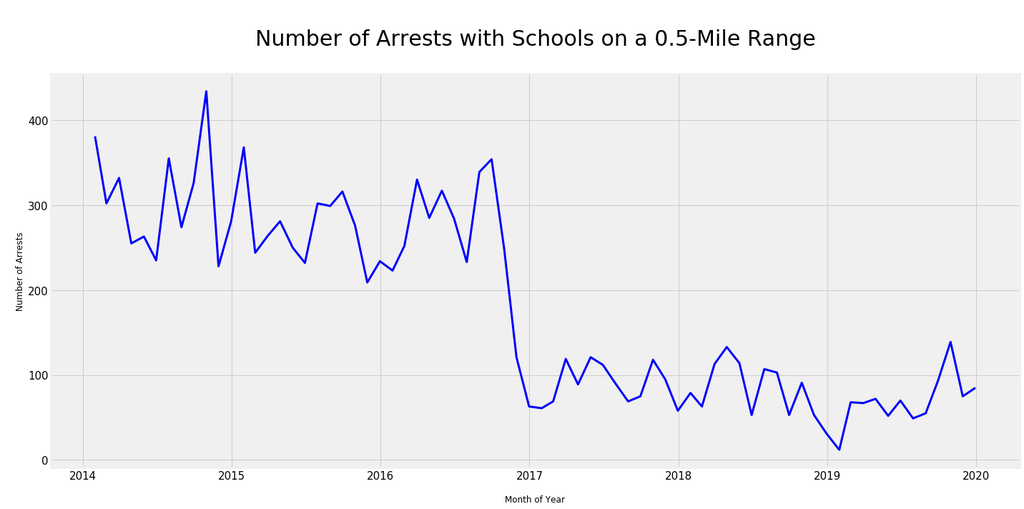

```python
# Number of arrests with a school in a 0.5-mile area

# Figure
plt.figure(figsize = (20,10))

# Plot data
plt.plot(df_arrests_half_mile_schools.resample('M').sum(), color = 'blue', linewidth = 3)

# Labels and Legend
plt.xticks(fontsize = 15)
plt.yticks(fontsize = 15)
plt.title('\nNumber of Arrests with Schools on a 0.5-Mile Range\n', fontsize = 30)
plt.xlabel('\nMonth of Year')
plt.ylabel('\nNumber of Arrests')
plt.tight_layout()
```

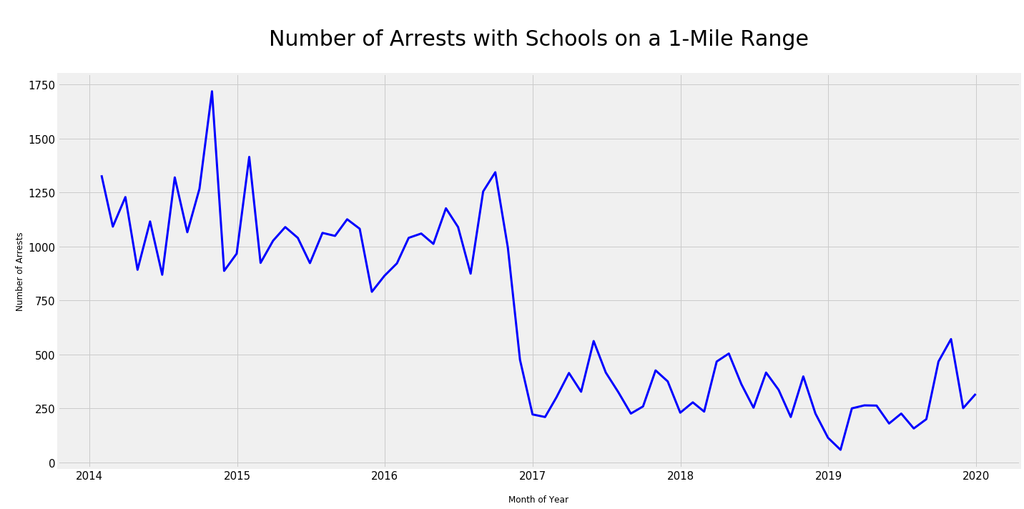

```python
# Number of arrests with a school in a 0.5-mile area

# Figure
plt.figure(figsize = (20,10))

# Plot data
plt.plot(df_arrests_one_mile_schools.resample('M').sum(), color = 'blue', linewidth = 3)

# Labels and Legend
plt.xticks(fontsize = 15)
plt.yticks(fontsize = 15)
plt.title('\nNumber of Arrests with Schools on a 1-Mile Range\n', fontsize = 30)
plt.xlabel('\nMonth of Year')
plt.ylabel('\nNumber of Arrests')
plt.tight_layout()
```

Something changed in 2017 that caused arrests near schools to drop. Was it marijuana legalization? I cannot be affirmed with total certainty, but everything thus far points on that direction. One important question is: Have the 'crimes' been reduced, or was this simply a change in how they are accounted for (what used to be a crime no longer is)?

### Top Reasons for Arrest

```python
# Function to plot the tally of arrests per crime on each year
def plot_total_crime_type(dataframe, year):

    # Filtering the dataframe by type of crime
    # Counting the number of occurances per type
    # Rearrange in ascending order
    # Create a bar plot
    ax = dataframe['Charge Description'].value_counts(ascending = True).tail().plot(kind = 'bar',
                                                                                    figsize = (16,10),
                                                                                    color = 'magenta',
                                                                                    alpha = 0.7,
                                                                                    rot = 30)

    ax.set_title(f'\nTally of Arrests per Crime Type in {year}\n', fontsize = 30)
    ax.set_ylabel('\nCrime Type\n', fontsize = 18);
    ax.set_xlabel('\nCrime Tally\n', fontsize = 18)
```

```python
# Before plotting the data there is an issue to fix on the dataset
# There are two entries for "possess 28.5 grams or less of marijuana"
# With the second one having an extra "**"
# Merging both those
df_arrests['Charge Description'] = df_arrests['Charge Description'].map(lambda x: 'possess 28.5 grams or less of marijuana' if x == 'possess 28.5 grams or less of marijuana**' else x)
```

```python
# Creating new dataframes per year
df_arrests_2014 = df_arrests[(df_arrests['Arrest Date'] <= '2014-12-31') & (df_arrests['Arrest Date'] >= '2014-01-01')]
df_arrests_2015 = df_arrests[(df_arrests['Arrest Date'] <= '2015-12-31') & (df_arrests['Arrest Date'] >= '2015-01-01')]
df_arrests_2016 = df_arrests[(df_arrests['Arrest Date'] <= '2016-12-31') & (df_arrests['Arrest Date'] >= '2016-01-01')]
df_arrests_2017 = df_arrests[(df_arrests['Arrest Date'] <= '2017-12-31') & (df_arrests['Arrest Date'] >= '2017-01-01')]
df_arrests_2018 = df_arrests[(df_arrests['Arrest Date'] <= '2018-12-31') & (df_arrests['Arrest Date'] >= '2018-01-01')]
df_arrests_2019 = df_arrests[(df_arrests['Arrest Date'] <= '2019-12-31') & (df_arrests['Arrest Date'] >= '2019-01-01')]
```

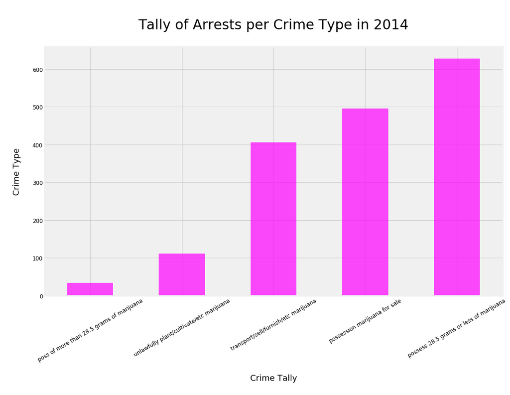

```python
# Total Arrests per Crime in 2014
plot_total_crime_type(df_arrests_2014, 2014)
```

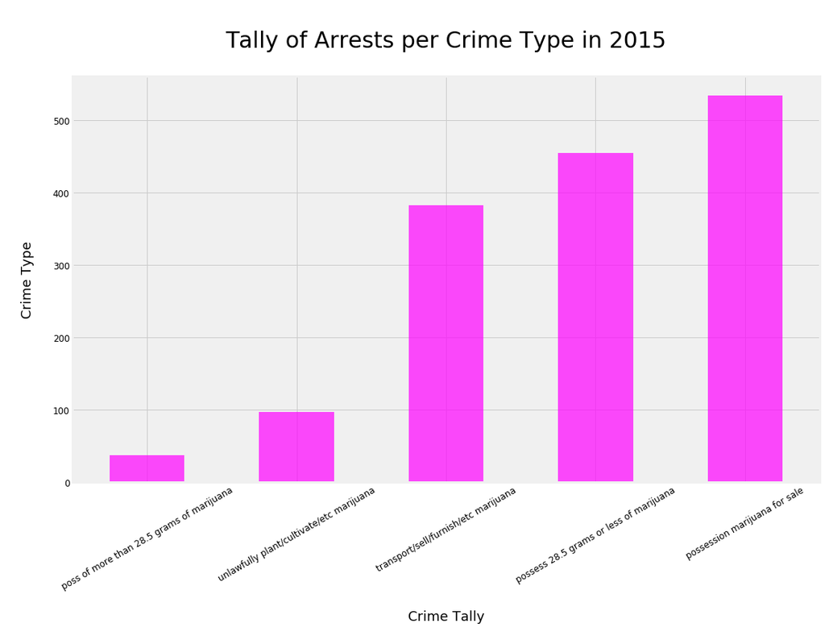

```python
# Total Arrests per Crime in 2015
plot_total_crime_type(df_arrests_2015, 2015)
```

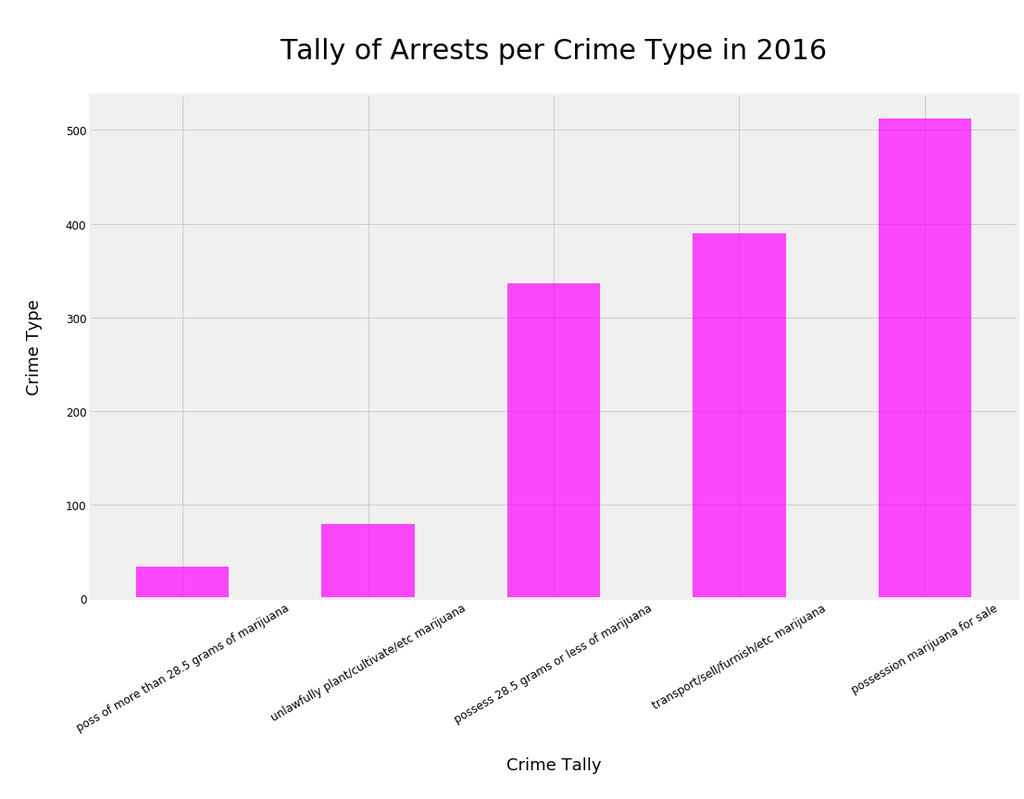

```python
# Total Arrests per Crime in 2016
plot_total_crime_type(df_arrests_2016, 2016)
```

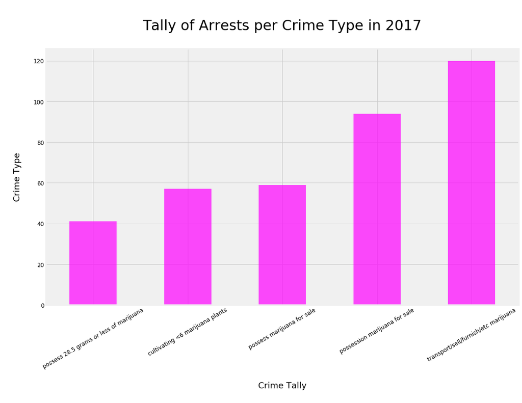

```python
# Total Arrests per Crime in 2017
plot_total_crime_type(df_arrests_2017, 2017)
```

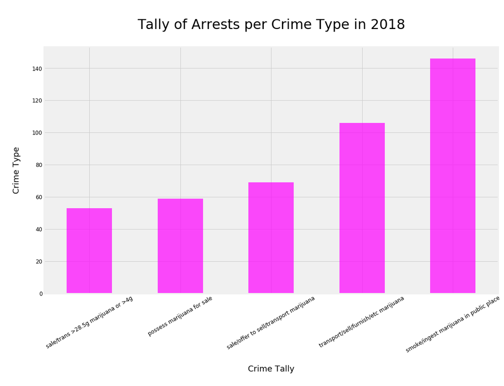

```python
# Total Arrests per Crime in 2018
plot_total_crime_type(df_arrests_2018, 2018)
```

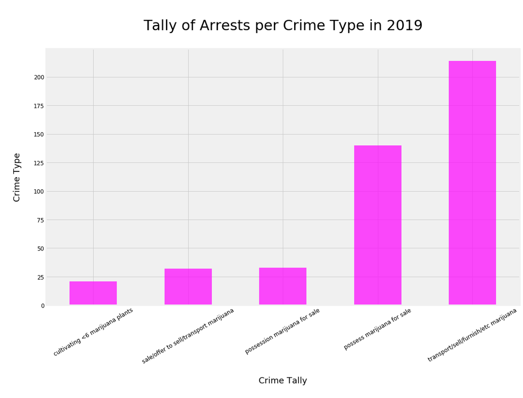

```python
# Total Arrests per Crime in 2019
plot_total_crime_type(df_arrests_2019, 2019)
```

### Statistical Modeling

```python
df_arrests.head()
```

|  | Report ID | Arrest Date | Time | Area ID | Area Name | Reporting District | Age | Sex Code | Descent Code | Charge Group Code | ... | Location | latitude | longitude | marijuana_related | store_0.5_mile_x | store_1_mile_x | store_0.5_mile_y | store_1_mile_y | school_0.5_mile | school_1_mile |
| --- | --- | --- | --- | --- | --- | --- | --- | --- | --- | --- | --- | --- | --- | --- | --- | --- | --- | --- | --- | --- | --- |
| 0 | 5568617 | 2019-03-09 | 2015.0 | 6 | Hollywood | 646 | 29 | M | O | 16.0 | ... | ['34.1016', '-118.335'] | 34.1016 | -118.3350 | possession marijuana for sale | 7 | 8 | 7 | 8 | 2 | 5 |
| 1 | 5568629 | 2019-03-09 | 2015.0 | 6 | Hollywood | 646 | 25 | M | B | 16.0 | ... | ['34.1016', '-118.335'] | 34.1016 | -118.3350 | possession marijuana for sale | 7 | 8 | 7 | 8 | 2 | 5 |
| 2 | 5607178 | 2019-04-21 | 2115.0 | 7 | Wilshire | 702 | 42 | M | B | 16.0 | ... | ['34.0838', '-118.3614'] | 34.0838 | -118.3614 | poss/sale marij ovr 21 employ per 20/belw | 4 | 13 | 4 | 13 | 4 | 8 |
| 3 | 5616516 | 2019-05-01 | 1045.0 | 14 | Pacific | 1494 | 26 | M | B | 16.0 | ... | ['33.9428', '-118.4054'] | 33.9428 | -118.4054 | sale/trans >28.5g marijuana or >4g | 0 | 0 | 0 | 0 | 0 | 0 |
| 4 | 5616188 | 2019-05-01 | 5.0 | 15 | N Hollywood | 1543 | 27 | M | B | 16.0 | ... | ['34.1667', '-118.3965'] | 34.1667 | -118.3965 | sale/trans >28.5g marijuana or >4g | 0 | 1 | 0 | 1 | 3 | 4 |

5 rows × 26 columns

```python
df_arrests.describe().T
```

|  | count | mean | std | min | 25% | 50% | 75% | max |
| --- | --- | --- | --- | --- | --- | --- | --- | --- |
| Report ID | 6226.0 | 4.834485e+07 | 6.881528e+07 | 2586.0000 | 4.350713e+06 | 4.811214e+06 | 1.410136e+08 | 2.006068e+08 |
| Time | 6226.0 | 1.510446e+03 | 5.321543e+02 | 1.0000 | 1.255000e+03 | 1.600000e+03 | 1.900000e+03 | 2.358000e+03 |
| Area ID | 6226.0 | 1.100594e+01 | 5.731738e+00 | 1.0000 | 6.000000e+00 | 1.200000e+01 | 1.500000e+01 | 2.100000e+01 |
| Reporting District | 6226.0 | 1.149005e+03 | 5.727965e+02 | 101.0000 | 6.460000e+02 | 1.235000e+03 | 1.546750e+03 | 2.197000e+03 |
| Age | 6226.0 | 3.049213e+01 | 1.134049e+01 | 12.0000 | 2.200000e+01 | 2.700000e+01 | 3.600000e+01 | 7.800000e+01 |
| Charge Group Code | 6226.0 | 1.600000e+01 | 0.000000e+00 | 16.0000 | 1.600000e+01 | 1.600000e+01 | 1.600000e+01 | 1.600000e+01 |
| latitude | 6226.0 | 3.406042e+01 | 1.145151e-01 | 33.7096 | 3.398750e+01 | 3.404770e+01 | 3.413495e+01 | 3.432860e+01 |
| longitude | 6226.0 | -1.183571e+02 | 9.521823e-02 | -118.6574 | -1.184335e+02 | -1.183337e+02 | -1.182783e+02 | -1.181624e+02 |
| store_0.5_mile_x | 6226.0 | 1.567298e+00 | 2.293777e+00 | 0.0000 | 0.000000e+00 | 0.000000e+00 | 2.000000e+00 | 1.100000e+01 |
| store_1_mile_x | 6226.0 | 4.098458e+00 | 4.885166e+00 | 0.0000 | 0.000000e+00 | 2.000000e+00 | 6.000000e+00 | 2.600000e+01 |
| store_0.5_mile_y | 6226.0 | 1.567298e+00 | 2.293777e+00 | 0.0000 | 0.000000e+00 | 0.000000e+00 | 2.000000e+00 | 1.100000e+01 |
| store_1_mile_y | 6226.0 | 4.098458e+00 | 4.885166e+00 | 0.0000 | 0.000000e+00 | 2.000000e+00 | 6.000000e+00 | 2.600000e+01 |
| school_0.5_mile | 6226.0 | 2.071314e+00 | 1.851271e+00 | 0.0000 | 1.000000e+00 | 2.000000e+00 | 3.000000e+00 | 1.100000e+01 |
| school_1_mile | 6226.0 | 7.819949e+00 | 5.686667e+00 | 0.0000 | 4.000000e+00 | 7.000000e+00 | 1.100000e+01 | 3.300000e+01 |

```python
df_arrests.dtypes
```

```
Report ID                     int64
Arrest Date                  object
Time                        float64
Area ID                       int64
Area Name                    object
Reporting District            int64
Age                           int64
Sex Code                     object
Descent Code                 object
Charge Group Code           float64
Charge Group Description     object
Arrest Type Code             object
Charge                       object
Charge Description           object
Address                      object
Cross Street                 object
Location                     object
latitude                    float64
longitude                   float64
marijuana_related            object
store_0.5_mile_x              int64
store_1_mile_x                int64
store_0.5_mile_y              int64
store_1_mile_y                int64
school_0.5_mile               int64
school_1_mile                 int64
dtype: object
```

```python
df_arrests.nunique()
```

```
Report ID                   6226
Arrest Date                 1691
Time                         430
Area ID                       21
Area Name                     21
Reporting District           904
Age                           66
Sex Code                       2
Descent Code                  10
Charge Group Code              1
Charge Group Description       1
Arrest Type Code               3
Charge                        31
Charge Description            31
Address                     2721
Cross Street                1142
Location                    3111
latitude                    1737
longitude                   1654
marijuana_related             32
store_0.5_mile_x              12
store_1_mile_x                26
store_0.5_mile_y              12
store_1_mile_y                26
school_0.5_mile               12
school_1_mile                 34
dtype: int64
```

```python
df_arrests_vars = df_arrests.describe().columns
```

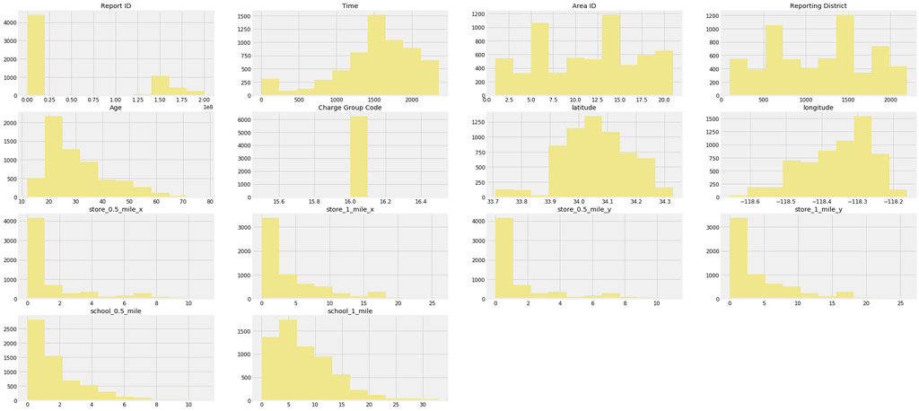

```python
# Histograms

# Figure
fig = plt.figure(figsize = (32,16))

# Plot a histogram of each variable
for i, col in enumerate(df_arrests_vars):
    fig.add_subplot(4,4,1+i)
    col_data = df_arrests[col]
    plt.hist(col_data, color = 'khaki')
    plt.title(col)
```

Looks like none of the variables follows a normal distribution. This can be later checked with am appropriate test!

```python
# Now moving to the schools dataframe
df_schools.describe()
```

|  | Zip Code | latitude | longitude | arrest_0.5_mile | arrest_1_mile |
| --- | --- | --- | --- | --- | --- |
| count | 906.000000 | 906.000000 | 906.000000 | 906.000000 | 906.000000 |
| mean | 90475.435982 | 34.060198 | -118.334404 | 14.233996 | 53.929360 |
| std | 587.265043 | 0.128336 | 0.116058 | 28.174758 | 68.352301 |
| min | 90001.000000 | 33.711431 | -118.654393 | 0.000000 | 1.000000 |
| 25% | 90026.000000 | 33.981266 | -118.422510 | 1.000000 | 12.000000 |
| 50% | 90063.000000 | 34.044304 | -118.298979 | 7.000000 | 32.000000 |
| 75% | 91306.750000 | 34.168790 | -118.251660 | 19.000000 | 73.750000 |
| max | 91754.000000 | 34.319027 | -118.152239 | 552.000000 | 677.000000 |

```python
df_schools_vars = ['arrest_0.5_mile', 'arrest_1_mile']
```

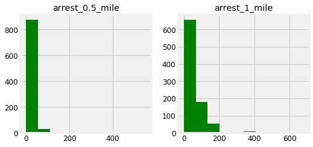

```python
# Histograms

# Figure
fig = plt.figure(figsize = (16,8))

# Plot a histogram of each variable
for i, col in enumerate(df_schools_vars):
    fig.add_subplot(2,4,1+i)
    col_data = df_schools[col]
    plt.hist(col_data, color = 'green')
    plt.title(col)
```

Again doesn't seem to be normally distributed.

### Normality Test

Quick Review: The p-value is the probability of obtaining a test statistic at least as extreme as the one observed when the null hypothesis is true. The null hypothesis (H0) affirms that the population is normally distributed, against the alternative hypothesis (H1) that it is not normally distributed.

```python
# Function to test variable normality
def test_normality(dataframe, list_of_cols, sig_level = 0.05):

    # List columns on dataframe
    total_variables = len(list_of_cols)

    # Start the counter of varibles which are 'non normal'
    not_normal_variables = 0

    # Loop through each column
    for col in list_of_cols:

        # Run the normality test (from statsmodels)
        p_val = stats.normaltest(dataframe[col])[1]

        # Significance Level
        sig_lvl = 0.05

        # Check p-value
        if p_val < sig_lvl:
            print(f'{col}')
            print(f'P-value: {p_val}\nSignificance Level: {sig_lvl}\n')
            print("The p-value is lower than the Significance Level, hence the null hypothesis is rejected and we conclude that the variable is not normally distributed.\n")
            not_normal_variables += 1
        elif p_val > sig_lvl:
            print(f'{col}')
            print(f'P-value: {p_val}\nSignificance Level: {sig_lvl}\n')
            print("The p-value is greater than the Significance Level, hence we fail to reject the null hypothesis that the variable is normally distributed.\n")

    if not_normal_variables > 0:
        print(f'{not_normal_variables} variables failed the normality test')
```

```python
# Test normality for arrests
test_normality(df_arrests, df_arrests_vars)
```

```
Report ID
P-value: 0.0
Significance Level: 0.05

The p-value is lower than the Significance Level, hence the null hypothesis is rejected and we conclude that the variable is not normally distributed.

Time
P-value: 3.7075045947738646e-165
Significance Level: 0.05

The p-value is lower than the Significance Level, hence the null hypothesis is rejected and we conclude that the variable is not normally distributed.

Area ID
P-value: 0.0
Significance Level: 0.05

The p-value is lower than the Significance Level, hence the null hypothesis is rejected and we conclude that the variable is not normally distributed.

Reporting District
P-value: 0.0
Significance Level: 0.05

The p-value is lower than the Significance Level, hence the null hypothesis is rejected and we conclude that the variable is not normally distributed.

Age
P-value: 1.1205894980358965e-190
Significance Level: 0.05

The p-value is lower than the Significance Level, hence the null hypothesis is rejected and we conclude that the variable is not normally distributed.

Charge Group Code
P-value: 0.0
Significance Level: 0.05

The p-value is lower than the Significance Level, hence the null hypothesis is rejected and we conclude that the variable is not normally distributed.

latitude
P-value: 8.438890053160126e-14
Significance Level: 0.05

```

[output cut: 30 more lines]

```
The p-value is lower than the Significance Level, hence the null hypothesis is rejected and we conclude that the variable is not normally distributed.

school_0.5_mile
P-value: 1.8728095723343848e-299
Significance Level: 0.05

The p-value is lower than the Significance Level, hence the null hypothesis is rejected and we conclude that the variable is not normally distributed.

school_1_mile
P-value: 1.0155192688748858e-236
Significance Level: 0.05

The p-value is lower than the Significance Level, hence the null hypothesis is rejected and we conclude that the variable is not normally distributed.

14 variables failed the normality test
```

```python
# Test normality for schools
test_normality(df_schools, df_schools_vars)
```

```
arrest_0.5_mile
P-value: 0.0
Significance Level: 0.05

The p-value is lower than the Significance Level, hence the null hypothesis is rejected and we conclude that the variable is not normally distributed.

arrest_1_mile
P-value: 2.8884711175727554e-161
Significance Level: 0.05

The p-value is lower than the Significance Level, hence the null hypothesis is rejected and we conclude that the variable is not normally distributed.

2 variables failed the normality test
```

Conclusion: None of the variables is normally distributed. This means that much caution is needed when creating the predictive models.

#### Final Conclusion

Clearly there seems to be a pattern between number of arrests and marijuana legalization. The proximity between arrests and dispensaries or schools doesn't seem to change from year to year, which seems to imply that there is no correlation between them. The important question to answer now is whether is there is some other factor which could better explain the drop in marijuana related crimes.